# Nonparametric Statistics - Epiphany term 2025

Jochen Einbeck

2025-03-20

# 1 Resampling methods

Michaelmas term material

# 2 Bayesian nonparametrics

Michaelmas term material

# 3 Density estimation

## 3.1 Introduction

Let $X$ be a continuous random variable (r.v.) with cumulative distribution function (c.d.f.) $F(x)=P(X\le x)$ and probability density function (p.d.f., “density”) $f=F'$. We are given data $x_1, \ldots, x_n \in \mathbb{R}$, which is considered an independent and identically distributed (i.i.d.) sample from $X$.

*Task*: Find an estimate of $f$.

Starting point: For any (fixed) $x \in \mathbb{R}$,

$$f(x)= \frac{d}{dx}F(x)= \lim_{h\longrightarrow 0} \frac{F(x+h)-F(x-h)}{2h}.$$
Note that this is a functional of $F$, so we can estimate it by replacing $F$ by its empirical distribution function (e.d.f.)
$$\hat{F}_n(x)= \frac{1}{n}\sum_{i=1}^n1_{\{x_i \le x\}}= \frac{\{\#x_i: x_i \le x\}}{n}.$$
So, for small $h>0$,
$$\hat{f}_n(x)= \frac{1}{2h}\frac{ \{\#x_i: x_i \in (x-h, x+h]\}}{n}$$
**Example 3.1**

Climate data from Durham University Observatory (Burt & Burt, 2022).

Daily maximum temperature data for 2021 ($n=363$).

```r
temp.data0<- read.table("https://www.maths.dur.ac.uk/users/jochen.einbeck/Data/temp.dat")
```

```r
dim(temp.data0)
```

```
## [1] 365   1
```

```r
head(temp.data0)
```

```
##     x
## 1 5.5
## 2 2.4
## 3 5.3
## 4 3.9
## 5 3.8
## 6 2.3
```

```r
sum(is.na(temp.data0))
```

```
## [1] 2
```

```r
temp.data<-na.omit(temp.data0[,1])
head(temp.data)
```

```
## [1] 5.5 2.4 5.3 3.9 3.8 2.3
```

```r
length(temp.data)
```

```
## [1] 363
```

```r
summary(temp.data)
```

```
##    Min. 1st Qu.  Median    Mean 3rd Qu.    Max.
##   -0.10    9.65   13.50   13.62   19.00   28.50
```

Implement $\hat{f}_n(x)$ as inspired above:

```r
my.density<- function(data,x,h){
  n<-length(data)
  denom<- 2*n*h
  num<- sum(data> x-h & data <= x+h)
  return(num/denom)
}
```

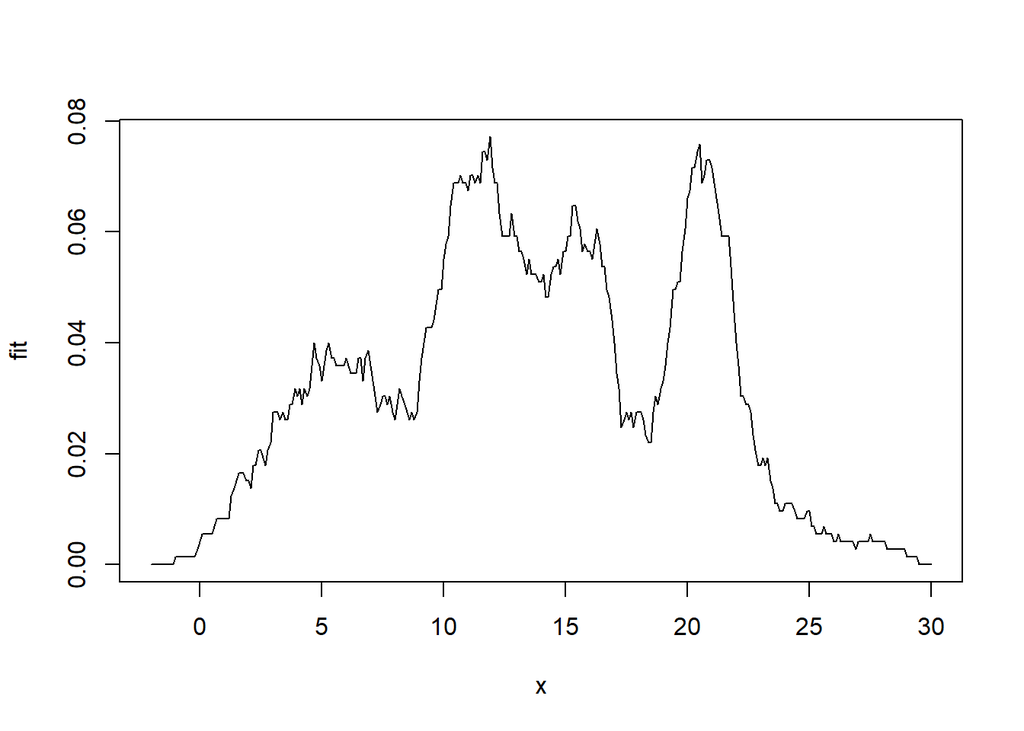

```r
x<- seq(-2,30, by=0.1)
G<-length(x)
fit<- rep(0,G)
for (j in 1: G){
  fit[j]<- my.density(temp.data,x[j],1)
}
plot(x, fit, type="l" )
```

This looks like a reasonably try, as it gives an impression of the shape of the underlying, true density ($f$), of the data. However, it is very jagged. Usually “nature is smooth”. Our density estimate should hence not appear as erratic.

There does exist a well-established graphical device, familiar to all of us, which can be used to obtain more “stable-looking” density estimates: the histogram. We’ll look at this traditional tool first, before we consider more advanced, modern density estimators.

## 3.2 The histogram

The histogram is the oldest and most widely used density estimator.

Basic idea: Rather than counting the data falling into $(x-h, x+h]$ for *all* possible values $x$, consider just a fixed set of bins of width $b (=2h)$.

**Example 3.2**

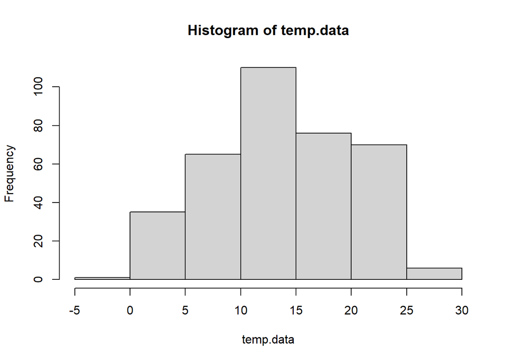

```r
hist(temp.data)
```

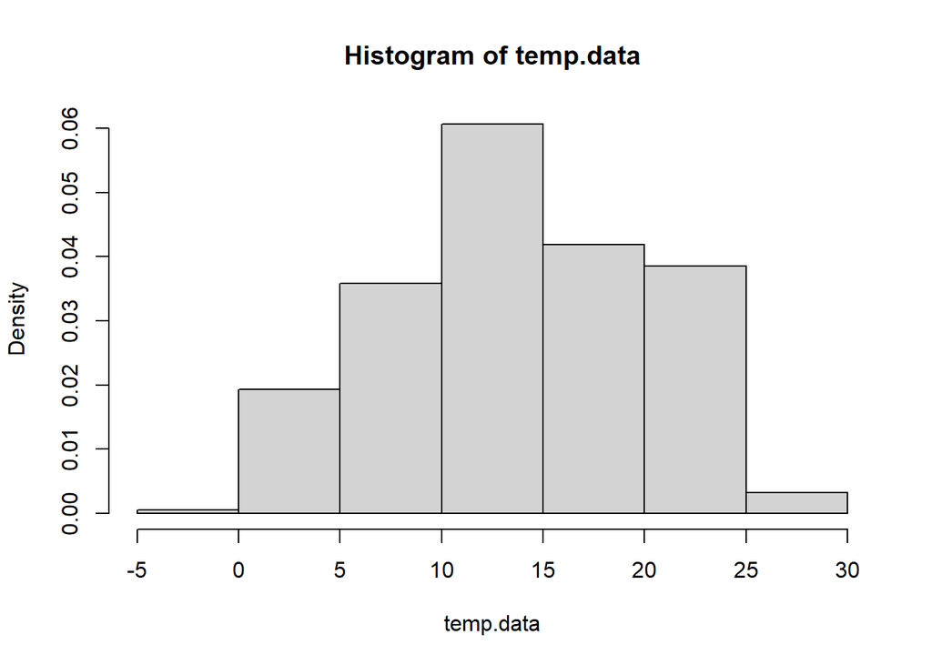

```r
hist(temp.data, freq=FALSE)
```

### 3.2.1 Constructing a histogram

- Divide the real line into equally sized intervals of fixed binwidth $b$.
- Count the number of observations falling into each bin, say $n_j$ observations in the $j$th bin.
- Then the height of the $j$th bin is given by
  $$\label{fj}
  f_j=\frac{n_j}{nb}$$
  (Why actually? Note that we would like the $j$th bin to represent the fraction $n_j/n$ of the probability mass. Hence we equate $f_j \times b = n_j/n$, and solving this w.r.t $f_j$ gives the equation above.)
- As a function of $x$,

$$\hat{f}_b(x)= \frac{\{\# \mbox{ observations in bin containing } x \}}{nb}.$$

One can interpret this as stacking blocks of height $\frac{1}{nb}$ and width $b$ on top of each other; that is one block for each observation.

For our developments we need a yet slightly more formal description of the histogram. For this, denote by $x_0$ the “origin” of the histogram, that is an arbitrary point on the real line where we put the left border of the “first” bin. The $j$th bin is then given by
$$B_j= (x_0+(j-1)b, x_0+jb]$$
for $j \in \mathbb{Z}$.

That is, for $x \in B_j$, we have
$$\hat{f}_b(x)= \frac{1}{nb}\sum_{i=1}^n 1_{B_j}(x_i)$$
where the indicator function is defined as
$$1_{B_j}(x_i)= \left\{\begin{array}{ll} 1 & \mbox{if } x_i \in B_j \\
0 & \mbox{otherwise}
\end{array}
\right.$$

### 3.2.2 Impact of $b$ and $x_0$:

**Example 3.3**

- Keep $x_0=0$, vary $b=1, \ldots 6$.

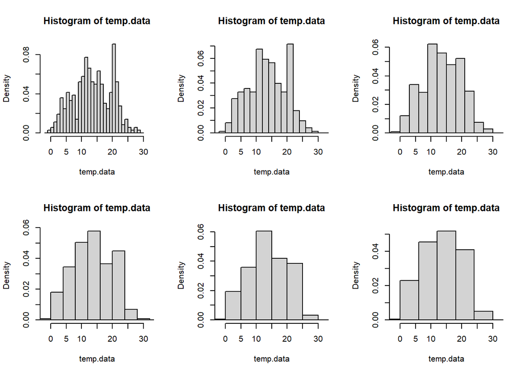

```r
par(mfrow=c(2,3))
x0<-0
bvec<-1:6
for (j in 1:6){
b<-bvec[j]
index<- -2:30
breaks= x0+ index*b
breaks
hist(temp.data, breaks=breaks, freq=FALSE, xlim=c(-2,32))
}
```

We see that

- for small values of $b$, the histogram appears very jagged.
- for high values of $b$, the histogram appears “smooth” (apart from the discontinuities due to the binning itself).

This is a typical case of a **bias-variance trade-off**: Small $b$ corresponds to low bias/high variance, and large $b$ corresponds to large bias/small variance. The binwidth $b$ plays the role of a “smoothing parameter” for the histogram. As we will see, it is possible to optimize it by calibrating bias and variance in a principled way (Section 3.2.5).

- Now we keep $b=3$, and vary $x_0=0,0.5, \ldots, 2.5$.

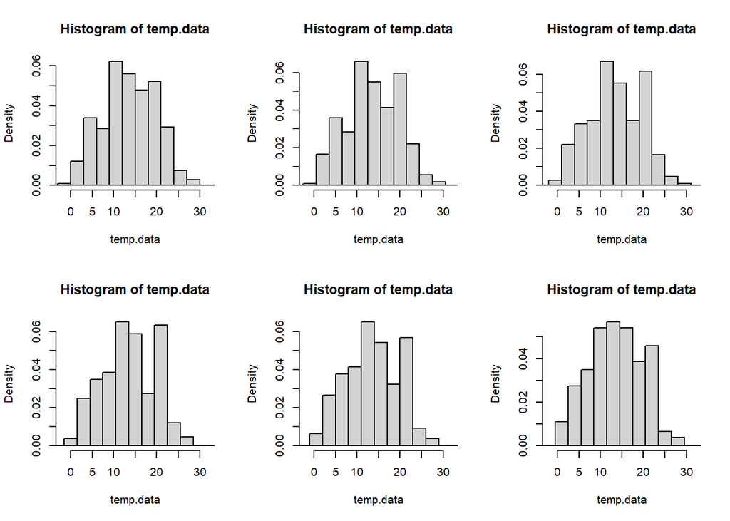

```r
par(mfrow=c(2,3))
b<-3
x0vec<-seq(0,2.5, by=0.5)
for (j in 1:6){
x0<-x0vec[j]
index<- -2:30
breaks= x0+ index*b
breaks
hist(temp.data, breaks=breaks, freq=FALSE, xlim=c(-2,32))
}
```

The quantity $x_0$ is a purely technical parameter which cannot be optimized. One can avoid the requirement to make this choice only by using an entirely different density estimation technique which does not require binning, and which is actually “smooth” (Section 3.3).

### 3.2.3 Bias and Variance of histogram

Without loss of generality (w.l.o.g.) say $x \in B_j$. We are interested in properties of $\hat{f}_b(x)=\frac{1}{nb}\sum_{i=1}^n 1_{B_j}(x_i)$ as an estimator of $f(x)$.

The key insight for this analysis is as follows: The random variable $1_{B_j}(x_i)$ is a Bernoulli variable with success probability

$$p_j=P(x_i \in B_j)= \int_{B_j}f(u)\,du = \int_{x_0+(j-1)b}^{x_0+jb} f(u)\,du$$
so that
$$E(1_{B_j}(x_i)) = p_j$$
and
$$\mbox{Var}(1_{B_j}(x_i)) = p_j(1-p_j).$$
Hence, we have
$$\begin{align}
\mbox{Bias}(\hat{f}_b(x)))&= E(\hat{f}_b(x))-f(x) = E\left(\frac{1}{nb}\sum_{i=1}^n1_{B_j}(x_i)\right)-f(x)=\\
&= \frac{1}{nb}\sum_{i=1}^nE1_{B_j}(x_i)-f(x)= \frac{1}{nb}np_j-f(x)= \frac{p_j}{b}-f(x)
\end{align}$$
which can be interpreted as the difference between $f(x)$ and the average value of $f$ within the interval. This is still not overly insightful. So let us try to look deeper into $p_j$ by expanding $f(u)$ around the value $x$, for small binwidths $(b << 1)$. Recall that $x \in B_j$, $u \in B_j$. Then a Taylor expansion gives

$$\begin{align}
f(u)& \approx f(x)+f'(x)(u-x)
\end{align}$$
based on the reasoning that, for small $b$, the expression $(u-x)^2$ and all higher-order terms become “very small” and hence negligible. So,

$$\begin{align}
p_j&= \int_{x_0+(j-1)b}^{x_0+jb}f(u)\,du \approx \int_{x_0+(j-1)b}^{x_0+jb}(f(x)+ f'(x) (u-x)) \, du\\
&= bf(x)+ f'(x)\left[\frac{u^2}{2}-ux\right]_{x_0+(j-1)b}^{x_0+jb}= \ldots =\\
&= bf(x)+bf'(x)\left[(x_0+(j-1/2)b)b -xb \right]=\\
&= bf(x)+bf'(x)(m_j-x)
\end{align}$$
where we have identified that $m_j\equiv x_0+(j-1/2)b$ is just the mid-point of the interval $B_j$.

Hence,
$$\begin{align}
\mbox{Bias}(\hat{f}_b(x)))&\approx \frac{1}{b}(b f(x)+ bf'(x)(m_j-x))-f(x)\\
&= f(x)+f'(x)(m_j-x)-f(x)\\
&= f'(x)(m_j-x)
\end{align}$$
From this we can see that

- there is approxmately no bias at the mid-points $m_j$.
- the bias is the larger, the larger the gradient of the density.

A pragmatic approximation of this bias term, which makes the dependency on the binwidth $b$ explicit, is given by

$$|\mbox{Bias}(\hat{f}_b(x))| \approx |f'(x)||m_j-x| \le \frac{b}{2}|f'(x)|$$
Hence, this gives an approximate measure of the “worst possible” bias, which is attained around the end points of the bins. We observe that from this perspective, small binwidths appear preferable to large binwidths. However, this is unlikely to suggest that small binwidths are preferable *per se*, since, as motivated earlier, the variance is likely to show the opposite behavior. So, let’s work this variance out. This is now quite straightforward as we have done all the hard work already.

$$\begin{align}
\mbox{Var}(\hat{f}_b(x))&= \frac{1}{n^2b^2}\sum_{i=1}^n\mbox{Var}(1_{B_j}(x_i))= \frac{1}{{n^2b^2}}n p_j(1-p_j)=\frac{1}{nb^2}p_j(1-p_j) \\
&\approx\frac{1}{nb}(f(x)+bf'(x)(m_j-x))(1-bf(x)-bf'(x)(m_j-x))\\
\end{align}$$
Hence, based on similar reasoning as above, we get an approximate quantification of the maximum variance as
$$\begin{align}
\mbox{Var}(\hat{f}_b(x))&\le \frac{1}{nb}(f(x)+|f'(x)|\frac{b}{2})(1-b(\ldots))\\
&\approx \frac{1}{nb}f(x)
\end{align}$$

We find that variance tends to zero if $b$ tends to infinity (or $n$ tends to infinity), indicating that a bias-variance trade-off between bias and variance is present. In the next section we aim to derive an optimal binwidth $b$ by exploiting this trade-off.

This set of calculations was admittedly a bit adventurous, but it sets out the philosophy of the calculations which we will carry out repeatedly in this term: Under the assumption of small binwidth (or other smoothing parameters, such as bandwidth), approximate bias and variance terms through Taylor expansions around the target point ($x$), and then omit all terms except the leading term. The resulting expressions give approximations for the bias and variance under small $b$ (and, sometimes, large $n$, but so far we did not do this).

### 3.2.4 MSE and consistency

From the approximate expression for (maximum) bias and variance, we obtain the (maximum) mean squared error (MSE) as

$$\begin{align}
\mbox{MSE}(\hat{f}_b(x))&= E\left[(\hat{f}_b(x)-f(x))^2\right] = \ldots=\\
&= \mbox{Bias}^2(\hat{f}_b(x))+\mbox{Var} (\hat{f}_b(x))\\
&\approx \frac{b^2}{4}(f'(x))^2+ \frac{1}{nb}f(x)
\end{align}$$
So $\hat{f}_b(x)$ is **mean square consistent** for f(x) if $b=b_n$ is a sequence such that, if $n \longrightarrow \infty$,

1. $b_n \longrightarrow 0$;
2. $nb_n \longrightarrow \infty$.

Does there exist such a sequence?

Let us define $M(b)= \frac{b^2}{4}(f'(x))^2+ \frac{1}{nb}f(x)$ and minimize this quantity w.r.t $b$.

So,

$$\begin{align}
\frac{dM(b)}{db}&= \frac{b}{2}(f'(x))^2
-\frac{1}{nb^2}f(x)\stackrel{!}{=}0\\
\frac{b^3}{2}(f'(x))^2&= \frac{1}{n}f(x)\\
b^3&= \frac{2}{n} \frac{f(x)}{(f'(x))^2} \\
b&= \left[2\frac{f(x)}{(f'(x))^2}\right]^{1/3}n^{-1/3}
\end{align}$$
So let’s check. Call $c(x)\equiv \left[2\frac{f(x)}{(f'(x))^2}\right]$ for ease of notation.

1. $c(x) \frac{1}{n^{1/3}} \longrightarrow 0$ for $n \longrightarrow \infty$
2. $n \times c(x) \frac{1}{n^{1/3}} = c(x) n^{2/3} \longrightarrow \infty$ for $n \longrightarrow \infty$

Hence, with $b=b_n= c(x)n^{-1/3}$, we have
$$\mbox{MSE}(\hat{f}_b(x)) \longrightarrow 0\,\,\,\, (n \longrightarrow \infty)$$
so $\hat{f}_b(x)$ is mean squared consistent for $f(x)$.

### 3.2.5 MISE and optimal binwidth

The result from Section 3.2.4 is still not useful: We want **one** optimal binwidth which does not depend on $x$.

To achieve this, we can consider the mean integrated squared error:

$$\begin{align}
\mbox{MISE}(\hat{f}_b)= \int_x\mbox{MISE}(\hat{f}_b(x))\,dx
&\approx \int \left(\frac{b^2}{4}(f'(x))^2+\frac{1}{nb}f(x)\right)\,dx\\
&= \frac{b^2}{4} \int (f'(x))^2\,dx + \frac{1}{nb}\int f(x)\,dx\\
&= D_1 \frac{b^2}{4} + \frac{1}{nb}
\end{align}$$
with constant $D_1\equiv \int f'(x)^2\,dx$, and noting that $\int f(x)\,dx=1$. Let us now denote $\tilde{M}(b)= D_1 \frac{b^2}{4} + \frac{1}{nb}$ and we minimize this expression w.r.t. $b$ as before.

Then
$$\begin{align}
\frac{d\tilde{M}(b)}{db}&= b\frac{D_1}{2}-\frac{1}{nb^2}\stackrel{!}{=}0\\
\frac{b^3D_1}{2}&= \frac{1}{n}\\
b&= \left(\frac{2}{D_1}\right)^{1/3}n^{-1/3}
\end{align}$$
Problem: We cannot compute $b$ since $f$ is unknown and hence $D_1=\int f'^{2}$ is unknown too. A solution is known as the “normal reference” method, where one takes, only for the sake of computing $D_1$, a normal distribution as a proxy for $f$ (Of course, this is not meaning that we assume $f$ to have *really* a normal distribution — if we did so then the entire exercise of computing a histogram density would be a bit pointless!).

So, let us take (for this purpose only) $f\sim N(0,\sigma^2)$. Let $f^{(j)}(x)$ denote the $j$th derivative of $f$. Denote also by $\phi$ the density of $N(0,1)$ and by $\phi^{(j)}$ its j-th derivative. For our calculations, we make use of the result (without proof, but it is easy to proof), that
$$\int (f^{(j)}(x))^2\,dx= \frac{1}{\sigma^{2j+1}}\int (\phi^{(j)}(x))^2\,dx$$
With this, we use
$$\begin{align}
\phi(x)&= \frac{1}{\sqrt{2\pi}}\exp(-\frac{x^2}{2})\\
\phi^{'}(x)&=-\frac{1}{\sqrt{2\pi}}x \exp(-\frac{x^2}{2})\\
\end{align}$$
and so can work out
$$\begin{align}
\int (\phi^{'}(x))^2 \,dx&= \int x^2 \frac{1}{2\pi}\exp(-x^2)\,dx \\
&= \frac{1}{\sqrt{2\pi}}\sqrt{\frac}{1}{2}\int x^2 \frac{1}{\sqrt{1/2}}\frac{1}{\sqrt{2\pi}}\exp{\left(\frac{x^2}{2\times \frac{1}{2}} \right)}\,dx\\
&= \frac{1}{\sqrt{4\pi}}\times \frac{1}{2}= \frac{1}{4\sqrt{\pi}}
\end{align}$$
where the equality sign leading to the last row makes use of the insight that the integral in the previous row is just the variance of a $N(0,1/2)$ distribution.

Hence with the helper tool above we have
$$\int (f'(x))^2\,dx= \frac{1}{\sigma^3}\frac{1}{4\sqrt{\pi}}$$

so that we are able to derive the MISE-optimal binwidth
$$b_{opt}= \left(\frac{2}{\frac{1}{4\sqrt{\pi}}\frac{1}{\sigma^3} }\right)^{\frac{1}{3}}n^{-\frac{1}{3}}= (8 \sqrt{\pi})^{1/3}\sigma n^{-1/3}= 2.42 \sigma n^{-1/3},$$
where $\sigma$ is usually estimated by the sample standard deviation, $s$.

Note that Scott (2015) obtains an equation involving a slightly larger constant, $3.5\sigma n^{-1/3}$, by employing a notion of “average bias” rather than “maximum bias” as we have used. However, this is not really important: What is important is to understand how the optimal binwidth evolves with $n$.

**Example 3.4**

```r
bopt<-function(vec){
  vec<-na.omit(vec)
  n<-length(vec)
  s<-sd(vec)
  b<- 2.42*s* n^(-1/3)
  return(b)
}
```

```r
bopt(temp.data)
```

```
## [1] 2.074377
```

```r
bscott<-function(vec){
  vec<-na.omit(vec)
  n<-length(vec)
  s<-sd(vec)
  b<- 3.5*s* n^(-1/3)
  return(b)
}
```

```r
bscott(temp.data)
```

```
## [1] 3.000132
```

For further calculations let us denote
$$b_{opt}= c \sigma n^{-1/3}$$
with $c$ chosen accordingly. The optimal binwidth is hence (approximately)
$$\begin{align}
\mbox{MISE}_{opt}(b)&= D_1\frac{b_{opt}^2}{4}+ \frac{1}{nb_{opt}}\\
&= D_1 \frac{c^2\sigma^2 n^{-2/3}}{4}+ \frac{1}{n c\sigma n^{-1/3}}\\
&= D_1 \frac{c^2\sigma^2}{4} n^{-2/3}+ \frac{1}{c\sigma} n^{-2/3}\\
&=O(n^{-{2/3}})
\end{align}$$
We say that the optimal MISE of histograms is of “order” $n^{-2/3}$, which mathematically means that the MISE, as a function of $n$, fulfils
$$\mbox{lim sup}_{n \longrightarrow \infty}\left|\frac{\mbox{MISE}_{opt}(b)}{n^{-2/3}} \right|< \infty$$
In more simple words, $\mbox{MISE}_{opt}(b)$ converges to 0 not slower than $n^{-2/3}$. We would want $\mbox{MISE}_{opt}(b)$ to converge to 0 “quickly”, so orders $n^{-r}$ for “large” $r$ are preferred. We can expect that any nonparametric estimator will not converge quicker than parametric ones: Parametric estimators are usually unbiased and achieve $n^{-1}$ rates by the Cramer-Rao bound. However, we will also see that there is quite some space between the rates $n^{-2/3}$ and $n^{-1}$ and we will find efficient density estimators which will fill this space.

## 3.3 Kernel density estimation

### 3.3.1 Kernel functions

Recall, from Section 3.1,
$$\begin{align}
\hat{f}_n(x)&= \frac{1}{2h}\frac{ \{\#x_i: x_i \in (x-h, x+h]\}}{n}\\
&= \frac{1}{nh} \sum_{i=1}^n \frac{1}{2}1_{\{(x-h, x+h)\}}(x_i)\\
&= \frac{1}{nh}\sum_{i=1}^nK\left(\frac{x_i-x}{h}\right)
\end{align}$$
where we have defined
$$K(u)=\frac{1}{2}1_{\{(-1,1)\}}(u)$$
which is a particular case of a **kernel** function (in this case the uniform kernel).

The uniform kernel is not a very good kernel. We can choose better ones which

- are (in some sense) smooth;
- give more weight to data points close to $x$;

for instance

- the Gaussian kernel

$$K(u)= \frac{1}{\sqrt{2\pi}}\exp\left(-\frac{u^2}{2}\right)$$

- the Epanechnikov kernel

$$K(u)= \frac{3}{4}(1-u^2)1_{|u|\le 1}$$
Formally, we call any function $K: \mathbb{R}\longrightarrow \mathbb{R}^+_0$ which is bounded, symmetric, unimodal, with $\int K(u)\,du=1$, a **kernel function** and
$$\hat{f}_h(x)= \frac{1}{nh}\sum_{i=1}^nK\left(\frac{x-x_i}{h}\right)$$
a **kernel density estimator** (KDE) (Note that, due to the symmetry of $K$, it is irrelevant whether we write $x-x_i$ or $x_i-x$ in the numerator; the formulation $x-x_i$ is more common in the literature).

**Example 3.5**

We firstly visualize the three mentioned kernel functions.

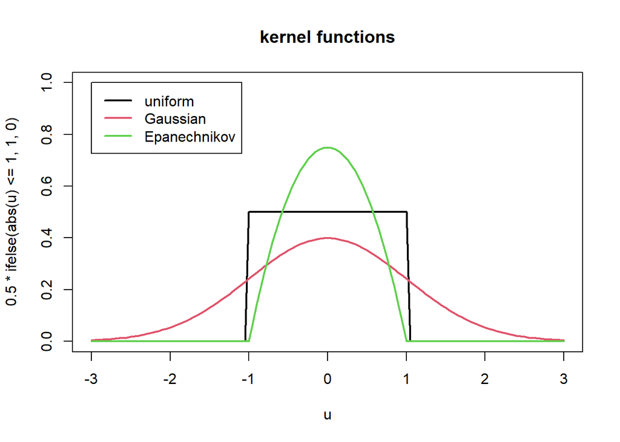

```r
u<-seq(-3,3, by=0.05)
plot(u, 0.5*ifelse(abs(u)<=1, 1,0), type="l", main="kernel functions", lwd=2, ylim=c(0,1))
lines(u, dnorm(u), lwd=2, col=2)
lines(u, 3/4*(1-u^2)*ifelse(abs(u)<=1,1,0), lwd=2, col=3)
legend(-3, 1, c("uniform", "Gaussian", "Epanechnikov"), lwd=c(2,2,2), col=c(1,2,3))
```

Then we implement a general version `my.density` of our kernel density estimator $\hat{f}_h(x)$, which can used in conjunction with any kernel `my.kernel`.

```r
my.kernel<-function(u){
  #u<- 0.5*ifelse(abs(u)<=1, 1,0)
  u<- dnorm(u)
  #u<- 3/4*(1-u^2)*ifelse(abs(u)<=1,1,0)
}
```

```r
my.density<- function(data,x,h){
  data<-na.omit(data)
  n<-length(data)
  denom<- n*h
  num<- sum(my.kernel((data-x)/h))
  return(num/denom)
}
```

We apply the KDE now on the Durham temperature data, for each value of grid ranging from -2 to 30, spaced by 0.1.

For the Gaussian kernel, the result is:

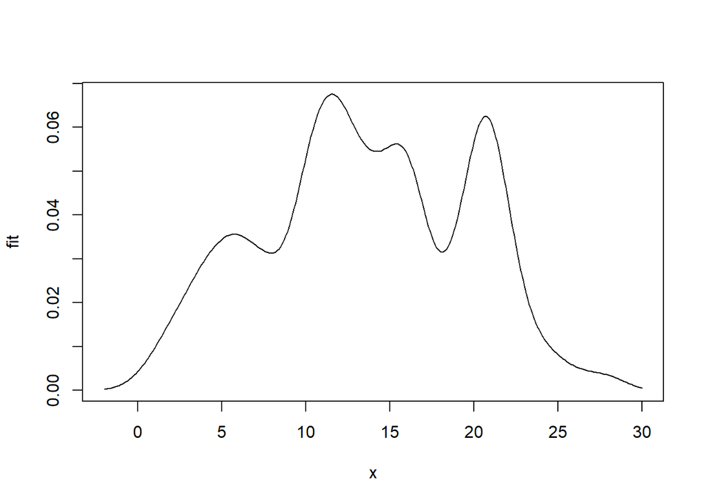

```r
x<- seq(-2,30, by=0.1)
G<-length(x)
fit<- rep(0,G)
for (j in 1: G){
  fit[j]<- my.density(temp.data,x[j],1) # uses h=1
}

plot(x, fit, type="l" )
```

This can be repeated for the other kernel functions by uncommenting the appropriate lines in the function `my.kernel`. For the uniform kernel, this will result in exactly the same estimator as previously shown in Example 3.1.

### 3.3.2 Basic features of KDEs

$\hat{f}_h(x)$ can be rewritten as

$$\hat{f}_h(x)= \frac{1}{n}\sum_{i=1}^n\frac{1}{h}K\left(\frac{x-x_i}{h}\right)\equiv \frac{1}{n}\sum_{i=1}^n K_h(x-x_i)$$
where $K_h(\cdot)=\frac{1}{h}K\left(\frac{\cdot}{h}\right)$ is a centered (at $x_i$) and rescaled kernel with

$$\begin{align}
\int K_h(x-x_i)\,dx&= \frac{1}{h}\int_{-\infty}^{\infty}K\left(\frac{x-x_i}{h}\right)\,dx\\
&= \frac{1}{h}\int_{-\infty}^{\infty}K(u)hdu=1.
\end{align}$$

With this we see

$$\begin{align}
\int \hat{f}_h(x)\,dx &=\int_{-\infty}^{\infty}\frac{1}{n}\sum_{i=1}^n K_h(x-x_i)\,dx\\
&= \frac{1}{n}\sum_{i=1}^n\int K_h(x-x_i) dx= \frac{1}{n} \times n \times 1=1
\end{align}$$
so that the estimated density always integrates to 1.

Further, we see that $\hat{f}_h(x)$ is a sum of $n$ ‘bumps’, positioned at the $x_i$, of size
$$\frac{1}{n}K_h(x-x_i),$$
each of these contributing a probability mass $1/n$. One can say that the KDE redistributes the point masses $\frac{1}{n}$ smoothly to the vicinity of each data point.

**Example 3.6** (Basu’s elephants)

Five elephants were famously weighed in Basu’s (1971) elephant fable: Combo (4675kg), Flimbo (3032kg), Linda (3328kg), Pamela (3427kg), and Sara (2910kg). Let’s produce a KDE of these:

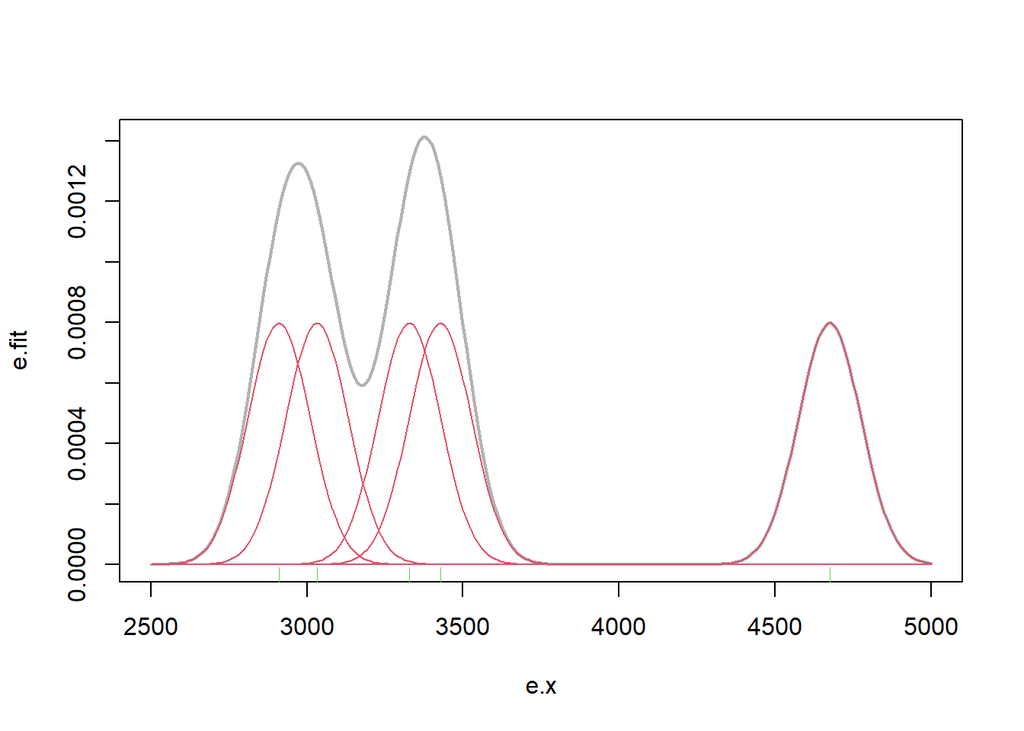

```r
elephants<- c(4675, 3032, 3328, 3427, 2910)
e.x <- seq(2500, 5000, by=10)
e.G    <- length(e.x)
e.fit  <- rep(0,e.G)
e.h    <- 100 # uses h=100 (arbitrary at this point)
for (j in 1: e.G){
  e.fit[j]<- my.density(elephants,e.x[j],e.h)
}

plot(e.x, e.fit, type="l", lwd=2, col="grey70" )
rug(elephants, col=3)

for (j in 1:5){
  lines(e.x, 1/(5*e.h)*my.kernel((e.x-elephants[j])/100), col=2)
}
```

### 3.3.3 Effect of bandwidth

**Example 3.7** (Back to Durham temperature data)

Firstly, let us put all our estimation components together, to have an easily usable function which does not require running iterations:

```r
est.density<- function(data, xgrid=data, h=1, kernel="gauss"){
  my.kernel<- switch(kernel,
                     "gauss"= function(x){dnorm(x)},
                     "epa"=function(x){x<- 3/4*(1-x^2)*ifelse(abs(x)<=1,1,0)},
                     "uni"=function(x){x<- 1/2*ifelse(abs(x)<=1,1,0)}
  )
  data<-na.omit(data)
  n<-length(data)
  g<-length(xgrid)
  est<-rep(0, g)
  denom<- n*h
  for (j in 1:g){
    num<- sum(my.kernel((data-xgrid[j])/h))
    est[j]<- num/denom
  }
  return(est)
}
```

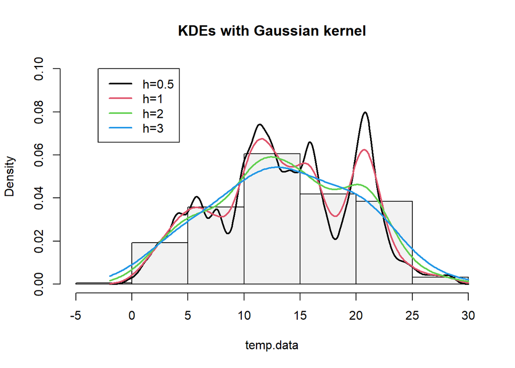

```r
x<- seq(-2,30, by=0.1)
hist(temp.data, freq=FALSE, ylim=c(0,0.1), main="KDEs with Gaussian kernel",  col="grey95")
lines(x,est.density(temp.data, x, h=0.5, "gauss"), col=1, lwd=2)
lines(x,est.density(temp.data, x, h=1, "gauss"), col=2, lwd=2)
lines(x,est.density(temp.data, x, h=2, "gauss"), col=3, lwd=2)
lines(x,est.density(temp.data, x, h=3, "gauss"), col=4, lwd=2)
legend(-3, 0.1, c("h=0.5","h=1", "h=2", "h=3"), lty=c(1,1,1,1), lwd=c(2,2,2,2), col=c(1,2,3,4))
```

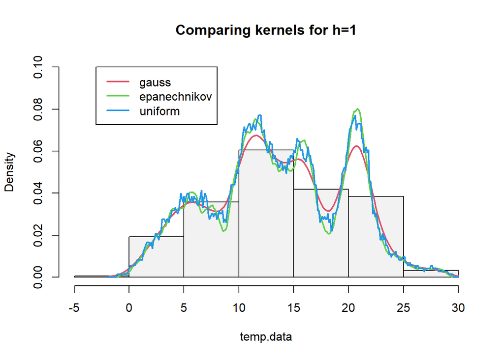

```r
x<- seq(-2,30, by=0.1)
hist(temp.data, freq=FALSE, ylim=c(0,0.1), main="Comparing kernels for h=1", , col="grey95")
lines(x,est.density(temp.data, x, h=1, "gauss"), col=2, lwd=2)
lines(x,est.density(temp.data, x, h=1, "epa"), col=3, lwd=2)
lines(x,est.density(temp.data, x, h=1, "uni"), col=4, lwd=2)
legend(-3, 0.1, c("gauss", "epanechnikov", "uniform"), lty=c(1,1,1), lwd=c(2,2,2), col=c(2,3,4))
```

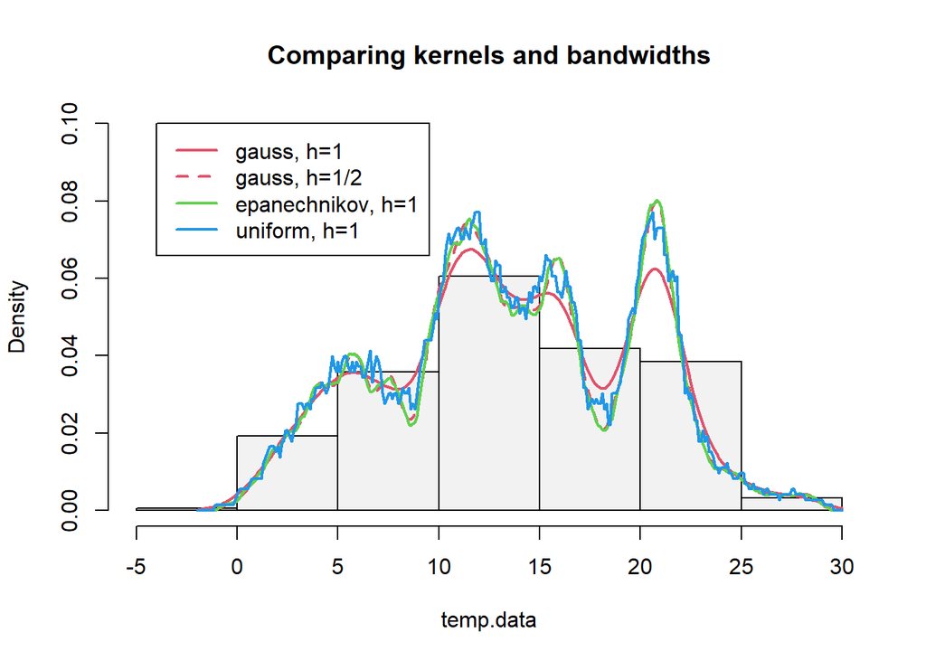

```r
x<- seq(-2,30, by=0.1)
hist(temp.data, freq=FALSE, ylim=c(0,0.1), main="Comparing kernels and bandwidths", col="grey95")
lines(x,est.density(temp.data, x, h=1, "gauss"), col=2, lwd=2)
lines(x,est.density(temp.data, x, h=1/2, "gauss"), col=2, lwd=2, lty=2)
lines(x,est.density(temp.data, x, h=1, "epa"), col=3, lwd=2)
lines(x,est.density(temp.data, x, h=1, "uni"), col=4, lwd=2)
legend(-4, 0.1, c("gauss, h=1", "gauss, h=1/2", "epanechnikov, h=1", "uniform, h=1"), lty=c(1,2,1,1), lwd=c(2,2,2,2), col=c(2,2,3,4))
```

The bandwidth, $h$, takes the role of a smoothing parameter, with

- $h$ small $\longrightarrow$ low bias, high variance
- $h$ large $\longrightarrow$ high bias, low variance

Something more subtle is going on when comparing different kernels: The same bandwidth does seem to imply a different degree of smoothness for different kernels. For instance, $h=0.5$ for the Gaussian kernel seems to give a similar degree of smoothness as $h=1$ for an Epanechnikov kernel.

We investigate the reason for this effect in the next subsection.

### 3.3.4 Comparing bandwidths across kernels

**Example 3.8**

Consider built-in R function `density`.

```r
temp.dens<- density(temp.data)
temp.dens
```

```
##
## Call:
##  density.default(x = temp.data)
##
## Data: temp.data (363 obs.);  Bandwidth 'bw' = 1.693
##
##        x                y
##  Min.   :-5.179   Min.   :0.0000106
##  1st Qu.: 4.511   1st Qu.:0.0030456
##  Median :14.200   Median :0.0267690
##  Mean   :14.200   Mean   :0.0257760
##  3rd Qu.:23.889   3rd Qu.:0.0452311
##  Max.   :33.579   Max.   :0.0609223
```

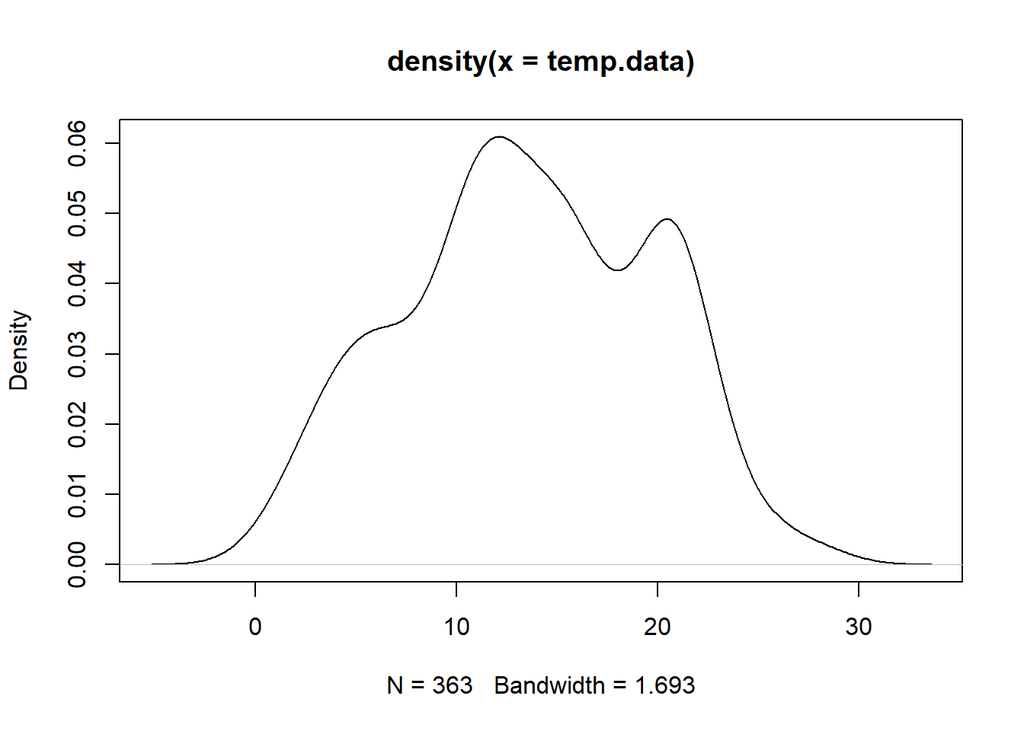

```r
# note bw=h=1.693 (for Gauss kernel)
plot(temp.dens)
```

The function `density` uses the Gaussian kernel is used by default. We also see that the output returns a result `Bandwidth 'bw' = 1.693`. How does this relate to “our” bandwidth $h$?

To answer this question, from the help file, we find that “The kernels are scaled such that this is the standard deviation of the smoothing kernel.”

Recall that
$$\hat{f}_h(x)= \frac{1}{n}\sum_{i=1}^n K_h(x-x_i)$$
is a sum of $n$ ‘bumps’, positioned at the $x_i$. Here, the $K_h(x_i-x)$ correspond to what is meant with “smoothing kernel”. These smoothing kernels are positioned at each $x_i$, and distribute the point mass of $x_i$ in the vicinity of $x_i$. We are interested in the standard deviation of this “redistribution”. So, for fixed $x_i$, consider (for a moment) $K_h(x-x_i)$ as the density of a random variable $\tilde{X}$, evaluated at $\tilde{X}=x$. So, the task is to work out $SD(\tilde{X})$ for the various kernel choices.

Therefore, we find firstly that
$$\begin{align}
\mbox{Var}(\tilde{X})&= E\left[(\tilde{X}-E\tilde{X}))^2 \right]\\
&= \int(x-x_i)^2\frac{1}{h}K\left(\frac{x-x_i}{h}\right)\, dx\\
&= h \int \left(\frac{x-x_i}{h}\right)^2K\left(\frac{x-x_i}{h}\right)\, dx\\
&= h^2 \int u^2K(u)\, du
\end{align}$$
where we have used in the first row that $E(\tilde{X})=x_i$ (obvious, as the bumps are symmetric and centered at the $x_i$), and later used the transformation $u= (x-x_i)/h$, which then implies $dx=h\,du$.

In the resulting expression, $\int u^2K(u)\,du$ is a “second kernel moment” which is often tabulated, for instance in Table B.2 of Wand and Jones (1995). For ease of access displayed here:

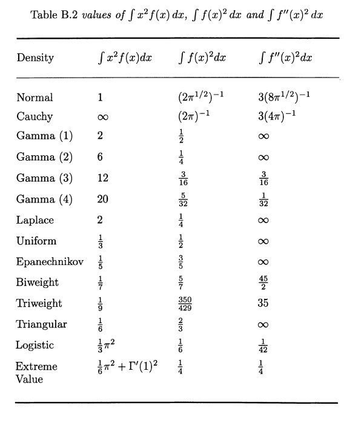

- For the Gaussian kernel, where $K(u)= \frac{1}{\sqrt{2\pi}}e^{-u^2/2}$, one has
  $$\int u^2K(u)\,du=1$$
  (we could have known this without the table too), and so
  $$SD(\tilde{X})=\sqrt{h^2 \times 1}=h$$
  That is for the Gaussian kernel, one has indeed just $\mbox{bw}=h$.
- For the uniform kernel, $K(u)=\frac{1}{2}1_{\{-1\le u \le 1\}}$,
  $$\int u^2K(u)\,du=\frac{1}{3}$$
  and so
  $$SD(\tilde{X})=\sqrt{h^2 \times \frac{1}{3}}=\frac{1}{\sqrt{3}}h$$
  Hence $\mbox{bw}= \frac{1}{\sqrt{3}}h =0.578\, h$ and
  $$h=1.73\,\mbox{bw}.$$
- Finally, for the Epanechniknov kernel, $K(u)= \frac{3}{4}(1-u^2)1_{\{|u|\le 1\}}$,
  $$\int u^2K(u)\,du = \frac{1}{5}$$
  and so
  $$SD(\tilde{X})=\sqrt{h^2 \times \frac{1}{5}}=\frac{1}{\sqrt{5}}h$$
  Hence $\mbox{bw}=\frac{1}{\sqrt{5}}h=0.447\, h$ and
  $$h=2.236\,\mbox{bw}.$$
  This result corresponds to the intuition from example 3.7 that, in order to attain the same degree of smoothness as the Epanechnikov kernel with bandwidth $h$, one needs a bandwidth of about
  $$\frac{1}{2.236}h \approx \frac{1}{2}h$$
  for the Gaussian kernel.

### 3.3.5 Statistical properties of the KDE

We consider initially a single point $x$ and investigate the properties (bias, variance, MSE) of $\hat{f}(x)$ as an estimator of $f(x)$.

In our calculations, we will assume that, for sufficiently small $h$, terms of order $h^{p+1}$ are negligible in comparison to $h^p$. That means, for instance,

$$ah^{p}+bh^{p+1}+ch^{p+2} = ah^p + O(h^{p+1})= ah^p + hO(h^{p})= ah^p+o(h^p)=h^p(a+o(1)).$$
Here, $O(h^p)$ signifies a term which grows at most proportional to $h^p$ for sufficiently small $h$, and $o(h^p)$ denotes a term that becomes asymptotically smaller than $h^p$ as $h\longrightarrow 0$.

(*Note*: On a more formal level, which is albeit not required for this course, the properties $o(\cdot)$ and $O(\cdot)$ are defined as follows (e.g. Wand & Jones, 1995). Let $a_n$ and $b_n$ be two real-valued deterministic sequences. Then

- $a_n=o(b_n)$ as $n \longrightarrow \infty$, if and only if $\lim_{n \longrightarrow \infty}\left|\frac{a_n}{b_n}\right|=0$
- $a_n=O(b_n)$ as $n \longrightarrow \infty$, if and only if $\text{limsup}_{n \longrightarrow \infty}\left|\frac{a_n}{b_n}\right|<\infty$

To reconcile these definitions with our setup, think of $h=h_n$ as a sequence such that $h_n \longrightarrow 0$ as $n\longrightarrow \infty$.)

We will make use of these notations systematically from now on. Hence, we will avoid using the $\approx$ symbol as we did in the histogram section, but will use equality symbols with appropriate order terms specified.

We also use the general notations $\mu_j=\int u^jK(u)\,du$ and $\nu_j=\int u^jK^2(u)\,du$.

Equipped with this, we calculate,

$$\begin{align}
E(\hat{f}_h(x))&= E\left(\frac{1}{nh}\sum_{i=1}^nK\left(\frac{x-x_i}{h}\right) \right)=\\
&= \frac{1}{nh}\sum_{i=1}^nE\left(K\left(\frac{x-x_i}{h}\right)\right)\\
&\stackrel{x_i \text{ iid}}{=} \frac{1}{h}E\left(K\left(\frac{x-x_i}{h}\right)\right)\\
&= \frac{1}{h}\int K\left(\frac{x-z}{h}\right)f(z)\,dz= \frac{1}{h}\int K\left(\frac{z-x}{h}\right)f(z)\,dz\\
&\stackrel{u=(z-x)/h}{=} \frac{1}{h}\int K(u)f(x+hu)h\,du\\
&= \int K(u)\left(f(x)+(hu)f'(x)+ \frac{1}{2}(hu)^2f^{''}(x)+ \frac{1}{6}(hu)^3f^{'''}(x)+\ldots\right)\\
&=f(x) \underbrace{\int K(u)\,du}_{=1} +hf'(x) \underbrace{\int uK(u)\,du}_{=0} + \frac{h^2}{2}f^{''}(x)\underbrace{\int u^2K(u)\,du}_{\equiv \mu_2} +O(h^3) \\
&= f(x)+ \frac{h^2}{2}f^{''}(x)\mu_2+\underbrace{O(h^3)}_{=hO(h^2)=o(h^2)}
\end{align}$$
Hence, we get the expression for the bias as

$$\mbox{Bias}(\hat{f}(x))= E\hat{f}_h(x)-f(x)=\frac{h^2}{2}f''(x)\mu_2+o(h^2)$$
Therefore, the bias will increase when $h$ is larger, or when the curvature of the density is larger.

For the variance, we calculate
$$\begin{align}
\mbox{Var}(\hat{f}_b(x))&=\mbox{Var}\left(\frac{1}{nh}\sum_{i=1}^nK\left(\frac{x-x_i}{h}\right) \right)\\
&=\frac{1}{n^2h^2}\sum_{i=1}^n\mbox{Var}\left(K\left(\frac{x-x_i}{h}\right)\right)\\
&\stackrel{\text{iid}}{=}\frac{1}{nh^2}\mbox{Var}\left(K\left(\frac{x-x_i}{h}\right)\right)\\
&= \frac{1}{nh^2}\left[E\left(K^2\left(\frac{x-x_i}{h}\right)\right)- \left[E\left(K\left(\frac{x-x_i}{h}\right)\right) \right]^2 \right]\\
&=\frac{1}{nh^2}\left[\int K^2\left(\frac{x-z}{h}\right)f(z)\,dz- \left[h\underbrace{\left(f(x)+\frac{h^2}{2}f^{''}(x)\mu_2)+o(h^2)\right)}_{\mbox{from bias calculation}}\right]^2 \right]\\
&=\frac{1}{nh^2}\left[\int K^2(u)f(x+hu)h\,du -h^2O(1) \right]\\
&=\frac{1}{nh^2}\left[\int K^2(u)(f(x)+ huf'(x)+O(h^2))h\,du -h^2O(1) \right]\\
&=\frac{1}{nh}\left[f(x)\underbrace{\int K^2(u)\,du}_{\nu_0}+\underbrace{O(h)}_{=h\times O(1)=o(1)}\right]\\
&=\frac{1}{nh}f(x)\nu_0+o\left(\frac{1}{nh}\right)
\end{align}$$

This is a similar formula as for the histogram. The variance gets larger if $nh$ is small or if $f(x)$ is large.

In summary we have
$$\mbox{MSE}(\hat{f}_h(x))= \frac{h^4}{4}(f^{''}(x))^2\mu_2^2+\frac{1}{nh}f(x)\nu_0+o(h^4)+o\left(\frac{1}{nh}\right)$$
So, we again find that $\hat{f}_h(x)$ is mean square consistent if $h\equiv h_n$ is a sequence such that, if $n \longrightarrow \infty$

1. $h_n\longrightarrow 0$
2. $nh_n \longrightarrow \infty$

To find such a sequence, let us proceed to the MISE directly (noting our experience with the histogram!)

### 3.3.6 MISE and optimal bandwidth

Consider the integrated MSE

$$\begin{align}
\mbox{MISE}(\hat{f}_h)&= \int \mbox{MSE}\left(\hat{f}_h(x)\right)\,dx\\
&= \frac{h^4}{4}\mu_2^2\int f^{''}(x)^2\,dx+\frac{1}{nh}\int f(x)\,dx+o(h^4)+o\left(\frac{1}{nh}\right)\\
&\approx \frac{h^4}{4}\mu_2^2 \int f^{''}(x)^2\,dx +\frac{1}{nh}\nu_0 \\
&\equiv \mbox{AMISE}(\hat{f}_h)
\end{align}$$
where the notation AMISE stands for “Approximated” MISE.

Taking derivatives,

$$\frac{d \mbox{AMISE}(\hat{f}_h)}{d h}= h^3\mu_2^2\int f^{''}(x)^2\,dx- \frac{1}{nh^2}\nu_0 \stackrel{!}{=}0$$
Hence

$$\begin{align}
h^5\mu_2^2\int f^{''}(x)^2\,dx&=\frac{\nu_0}{n}\\
h^5&= \frac{1}{n}\frac{\nu_0}{\mu_2^2}\frac{1}{\int f^{''}(x)^2\,dx}\\
h_{opt}&= \left(\frac{\nu_0}{\mu_2^2 \int f^{''}(x)^2\,dx}\right)^{1/5}n^{-1/5}\equiv cn^{-1/5}
\end{align}$$
We verify

- Clearly $h_{opt}\longrightarrow 0$ (as $n \longrightarrow \infty$)
- $n\times h_{opt}= c n n^{-1/5}= cn^{4/5} \longrightarrow \infty$ (as $n \longrightarrow \infty$)

so using this optimal bandwidth, $\hat{f}_h(x)$ is mean squared consistent as an estimator of $f(x)$ (see end of last subsection). Furthermore,

$$\mbox{AMISE}= \frac{c^4}{4}n^{-4/5}\mu_2^2\int f^{''}(x)^2\,dx+\frac{\nu_0}{cn^{4/5}}= O(n^{-4/5}).$$
Since the remainder terms in the MISE are of a negligible order compared to the AMISE terms, this actually implies
$$\mbox{MISE}= O(n^{-4/5})$$

We conclude that the optimal bandwidth leads to a MISE of order $n^{-4/5}$ which is *better* than the convergence order of $n^{-2/3}$ observed for the histogram estimators.

### 3.3.7 Normal reference bandwidth for KDEs

The equation for $h_{opt}$ derived in the previous subsection is still not useful as it depends on the unknown quantity

$$\int f{''}(x)^2\,dx.$$
Again we use the concept of “normal reference” to find a proxy for this quantity. So, take for a moment $N(0, \sigma^2)$.

We know from previous considerations (Sec 3.2.5) that

$$\int f^{''}(x)^2\,dx = \frac{1}{\sigma^5}\int \phi^{''}(x)^2\,dx$$
and also (Sec 3.3.4, Table B.2) that
$$\int \phi^{''}(x)^2\,dx= \frac{3}{8 \sqrt{\pi}}.$$
Hence, we can put things together as
$$h_{opt}= \left(\frac{8 \sqrt{\pi}\nu_0}{3 \mu_2^2} \right)\sigma \times n^{-1/5}.$$
The constants $\mu_2^2$ and $\nu_0$ are “kernel moments” which can be easily computed for specific kernels. Specifically, for the Gaussian kernel $K(u)=\frac{1}{\sqrt{2\pi}}e^{-u^2/2}$, one finds, invoking again Table B.2, that

$$\begin{align}
\mu_2&= \int u^2 K(u)\,du =1\\
\nu_0&= \int K^2(u)\,du = \frac{1}{2\sqrt{\pi}}
\end{align}$$
So we have
$$h_{opt}= \left(\frac{8\sqrt{\pi}/(2\sqrt{\pi})}{3 \times 1^2} \right)\sigma \times n^{-1/5}= \left(\frac{4}{3}\right)^{1/5}\sigma n^{-1/5}.$$

Several choices have been suggested for the estimation of $\sigma$:

- The sample standard deviation,

$$\hat{\sigma}= s= \frac{1}{n-1}\sum_{i=1}^n(x_i-\bar{x})^2$$

- A rescaled version of the IQR, robust to outliers (see also Lab 5):

$$\hat{\sigma}= \frac{IQR}{1.34}$$

- The minimum of the two, robust to multimodulalities:

$$\hat{\sigma}= \mbox{min}\left\{s, \frac{IQR}{1.34}\right\}$$

Using the latter option leads to the “rule of thumb estimator”

$$h_{ROT}= 1.06 \times \mbox{min}\left\{s, \frac{IQR}{1.34}\right\}n^{-1/5},$$
Due to likely underestimation of $\int f^{''}(x)^2\,dx$, Silverman (1986) proposed an alternative constant, 0.9, yielding

$$h_{Sil}= 0.9 \times \mbox{min}\left\{s, \frac{IQR}{1.34}\right\}n^{-1/5}$$
**Example 3.9**

```r
h.rot<- function(data){
  data<-na.omit(data)
  n<-length(data)
  sigma<-min(sd(data), IQR(data)/1.34)
  hopt<- 1.06*sigma*n^(-1/5)
  return(hopt)
}
```

```r
h.rot(temp.data)
```

```
## [1] 1.99388
```

```r
h.sil<- function(data){
  data<-na.omit(data)
  n<-length(data)
  sigma<-min(sd(data), IQR(data)/1.34)
  hopt<- 0.9*sigma*n^(-1/5)
  return(hopt)
}
```

```r
h.sil(temp.data)
```

```
## [1] 1.692917
```

Note we have seen this value before!

```r
density(temp.data)
```

```
##
## Call:
##  density.default(x = temp.data)
##
## Data: temp.data (363 obs.);  Bandwidth 'bw' = 1.693
##
##        x                y
##  Min.   :-5.179   Min.   :0.0000106
##  1st Qu.: 4.511   1st Qu.:0.0030456
##  Median :14.200   Median :0.0267690
##  Mean   :14.200   Mean   :0.0257760
##  3rd Qu.:23.889   3rd Qu.:0.0452311
##  Max.   :33.579   Max.   :0.0609223
```

```r
density(temp.data, bw="nrd0")
```

```
##
## Call:
##  density.default(x = temp.data, bw = "nrd0")
##
## Data: temp.data (363 obs.);  Bandwidth 'bw' = 1.693
##
##        x                y
##  Min.   :-5.179   Min.   :0.0000106
##  1st Qu.: 4.511   1st Qu.:0.0030456
##  Median :14.200   Median :0.0267690
##  Mean   :14.200   Mean   :0.0257760
##  3rd Qu.:23.889   3rd Qu.:0.0452311
##  Max.   :33.579   Max.   :0.0609223
```

The bandwidth $h_{ROT}$ can also be selected via

```r
density(temp.data, bw="nrd")
```

```
##
## Call:
##  density.default(x = temp.data, bw = "nrd")
##
## Data: temp.data (363 obs.);  Bandwidth 'bw' = 1.994
##
##        x                y
##  Min.   :-6.082   Min.   :1.006e-05
##  1st Qu.: 4.059   1st Qu.:2.358e-03
##  Median :14.200   Median :2.360e-02
##  Mean   :14.200   Mean   :2.463e-02
##  3rd Qu.:24.341   3rd Qu.:4.484e-02
##  Max.   :34.482   Max.   :5.914e-02
```

### 3.3.8 Cross-validation

Recall

$$\begin{align}
\mbox{MISE}(\hat{f}_h)&= \int \mbox{MSE}(\hat{f}_h(x))\,dx\\
&= \int E\left(\hat{f}_h(x)-f(x) \right)^2\,dx\\
&= E \int \left(\hat{f}_h(x)-f(x) \right)^2\,dx
\end{align}$$
where the interchanging of the integral and the expectation operator is possible by Fubini’s theorem since the argument of the integral can be assumed bounded (the density is bounded and the kernel is bounded). [We do not strongly worry about such technicalities in this module!].

Rewriting this expression, we have

$$\mbox{MISE}(\hat{f}_h)= E\left( \int \hat{f}_h(x)^2\,dx -2 \int \hat{f}_h(x)f(x)\,dx + \int f(x)^2\,dx\right)$$
It is clear that the last term of this does not depend on $h$ at all, so it is irrelevant for the question of minimizing the MISE. Hence we can focus on minimizing the expression

$$E\int \hat{f}_h(x)^2\,dx -2E \int \hat{f}_h(x)f(x)\,dx$$
with respect to $h$. A problem is here that we still don’t know $f$ so we cannot directly evaluate the right-hand side expression. However, intuitively one would suggest that a Monte-Carlo version of $E \int \hat{f}_h(x)f(x)\,dx$ could be used here, that is to approximate this expectation by its empirical average,
$$\frac{1}{n}\sum_{i=1}^n\hat{f}_h(x_i)$$
This approximation turns out to be biased upwards, since the $x_i$ are firstly used to estimate the density $\hat{f}_h$, and then to evaluate it at exactly these points. The solution to this problem is, for evaluation of the $i$th data point $x_i$, to omit the value $x_i$ from the estimation of the density. This gives rise to the expression
$$\frac{1}{n}\sum_{i=1}^n\hat{f}_h^{(-i)}(x_i)$$
which, with the **leave-one-out** (LOO) estimator

$$\hat{f}^{(-i)}(x)= \frac{1}{n-1}\sum_{j=1, j\not=i}^n K_h(x-x_j),$$
is now an *unbiased* approximation of $E \int \hat{f}_h(x)f(x)\,dx$.

**Proof**:

We work out the expectation of the empirical average of the LOO estimators.

$$\begin{align}
E\left(\frac{1}{n}\sum_{i=1}^n \hat{f}_h^{(-i)}(x_i)\right)&= E( \hat{f}_h^{(-i)}(x_i))\\&=E\left( \frac{1}{n-1}\sum_{j=1, j\not=i}^n K_h(x_i-x_j) \right)\\
&\stackrel{iid}=E\left(K_h(x_i-x_j) \right)=\\
&= \int \int K_h(x-z)f(x,z)\,dx\,dz=\\
&\stackrel{indep.}{=}\int \int K_h(x-z)f(x)f(z)\,dx\,dz
\end{align}$$
We also see that
$$\begin{align}
E\left(\int \hat{f}_h(x)f(x)\,dx\right)
&=E\left(\int \frac{1}{n}\sum_{i=1}^nK_h(x-x_i)f(x)\,dx \right)\\
&= \frac{1}{n}\sum_{i=1}^n\int EK_h(x-x_i)f(x)\,dx\\
&= \int \left(\int K_h(x-z)f(z)\,dz \right) f(x)\,dx\\
&= \int\int K_h(x-z)f(x)f(z)\,dz
\end{align}$$
so that the two expectations correspond to each other.

We will refer to the resulting criterion as “cross-validation” criterion, $CV(h)$. In the literature it is also known as “least-squares cross-validation” (LSCV) or as “cross-validation estimator of risk”. We have

$$CV(h)= \int \hat{f}_h(x)^2\,dx-\frac{2}{n}\sum_{i=1}^n\hat{f}_h^{-i}(x_i)$$
Of course, the first integral needs to be computed here as well, this can be done through integration techniques based on the estimated density; we do not delve deeper into this but leave this one for software to sort out.

The CV selector of the bandwidth $h$ is then given by

$$h_{CV}= \mbox{arg min}_h CV(h)$$

**Example 3.10**

The `density()` function supports the cross-validation technique via the option `ucv` (unbiased cross-validation).

```r
density(temp.data, bw="ucv")
```

```
##
## Call:
##  density.default(x = temp.data, bw = "ucv")
##
## Data: temp.data (363 obs.);  Bandwidth 'bw' = 0.7744
##
##        x                y
##  Min.   :-2.423   Min.   :1.637e-05
##  1st Qu.: 5.888   1st Qu.:6.354e-03
##  Median :14.200   Median :3.050e-02
##  Mean   :14.200   Mean   :3.005e-02
##  3rd Qu.:22.512   3rd Qu.:5.309e-02
##  Max.   :30.823   Max.   :7.040e-02
```

```r
bw.ucv(temp.data)
```

```
## [1] 0.7743859
```

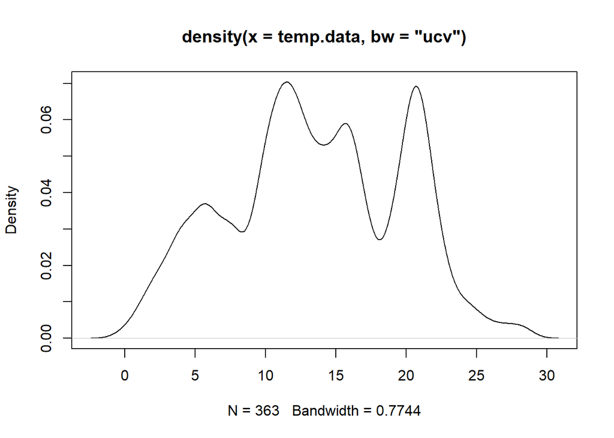

```r
plot(density(temp.data, bw="ucv"))
```

The resulting bandwidth of $h=0.7744$ looks very small in comparison to previously computed bandwidths for this data set. Have we perhaps got trapped in a local minimum of $CV(h)$? We hence investigate a bit further, and look for a function in R which allows us to produce the complete cross-validation curve $CV(h)$. We find such a function in R package `locfit`. Please note the unusual bandwidth scaling in locfit (`?lscv.exact`); we need to multiply “our” bandwidth by 2.5 to put the estimates on the same scale.

```r
require(locfit)
```

```
## locfit 1.5-9.11   2025-01-27
```

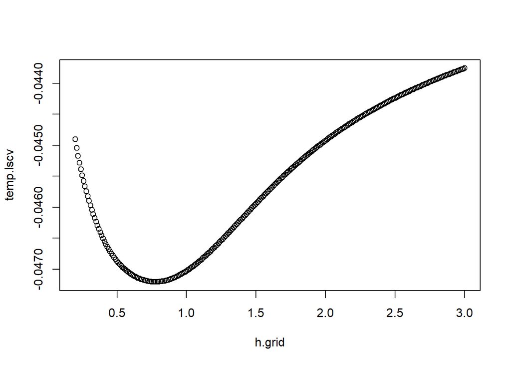

```r
h.grid<-seq(0.2,3, by=0.01)
h.length<-length(h.grid)
temp.lscv<- rep(0, h.length)
for (j in 1:h.length){
temp.lscv[j]<- lscv.exact(temp.data,h=2.5*h.grid[j])[1]
}
plot(h.grid, temp.lscv)
```

```r
h.grid[which.min(temp.lscv)]
```

```
## [1] 0.78
```

The resulting minimum at 0.78 is very close to 0.7744 so that there is not any doubt on the correctness of this value! The cross-validation technique settles on a very small bandwidth here. Looking at the density estimate above, it may be that the technique tries somewhat “too hard” too maintain the various modes in the data set.

### 3.3.9 Asymptotic normality and confidence intervals

We consider the usual KDE and rewrite

$$\hat{f}_h(x)=\frac{1}{nh}\sum_{i=1}^nK\left(\frac{x-x_i}{h}\right)=\frac{1}{n}\sum_{i=1}^nK_h(x-x_i)\equiv \frac{1}{n}\sum_{i=1}^n y_i$$
where

$$y_i=K_h(x-x_i)=\frac{1}{h}K\left(\frac{x-x_i}{h} \right)$$
can be considered as i.i.d. random variables. With this notation,
$$\hat{f}_h(x)=\frac{y_1+ \ldots+ y_n}{n}\equiv \bar{y}$$
is just the sample mean of the $y_i$, and gence the Lindeberg-Feller CLT applies

$$\frac{\bar{y}- E(\bar{y})}{\mbox{Var}(\bar{y})} \stackrel{d}{\longrightarrow} N(0,1),$$
where the notation $\stackrel{d}{\longrightarrow}$ means “convergence in distribution”, that is, when considered as a random variable, the CDF of the left hand side would converge to the CDF of the right hand side (at each point where that CDF is continuous), as $n \longrightarrow \infty$.

In the above,

$$\begin{align}
\bar{y}&= \hat{f}_h(x)\\
E(\bar{y})&= f(x)+\frac{h^2}{2}f''(x)\mu_2+O(h^3)\\
\mbox{Var}(\bar{y})&=\frac{1}{nh}f(x)\nu_0+o\left(\frac{1}{nh}\right)
\end{align}$$
From this we have

$$\frac{\hat{f}_h(x)-f(x)-\frac{h^2}{2}f''(x)\mu_2+O(h^3) }
{\sqrt{\frac{1}{nh}f(x)\nu_0+o\left(\frac{1}{nh} \right)}}\stackrel{d}{\longrightarrow} N(0,1).$$

We can rewrite this as

$$\sqrt{nh}\,\frac{\hat{f}_h(x)-f(x)-\frac{h^2}{2}f^{''}(x)\mu_2+O(h^3)}{\sqrt{f(x)\nu_0+o(1)}}\stackrel{d}{\longrightarrow} N(0,1)$$
Now, it is clear that the term $o(1)$ in the denominator vanishes if $n$ tends to infinity, so it becomes irrelevant for the distributional statement being made. Hence, the property remains true if it is omitted, and so we can say

$$\sqrt{nh}\left(\hat{f}_h(x)-f(x)-\frac{h^2}{2}f^{''}(x)\mu_2+O(h^3) \right)\stackrel{d}{\longrightarrow} N(0,f(x)\nu_0).$$
Based on this, we would *like to say* that

$$\sqrt{nh}\left(\hat{f}_h(x)-f(x) \right)\stackrel{d}{\longrightarrow} N(0,f(x)\nu_0),$$
as this would imply that, for large $n$,

$$P\left(\hat{f}_h(x)-z_{1-\alpha/2}\sqrt{\frac{f(x)\nu_0}{nh}}\le f(x)\le \hat{f}_h(x)+z_{1-\alpha/2}\sqrt{\frac{f(x)\nu_0}{nh}}\right)$$
and hence

$$\hat{f}_h(x)\mp z_{1-\alpha/2}\sqrt{\frac{\hat{f}_h(x)\nu_0}{nh}}$$

could be used as an approximate $(1-\alpha)$ confidence interval for $f(x)$.

**However**, this would require the bias terms $\frac{h^2}{2}f^{''}(x)\mu_2+O(h^3)$ to get asymptotically erased when mutiplying with $\sqrt{nh}$. Is this the case?

- For the $O(h^3)$ term, $\sqrt{nh}O(h^3)= O(n^{1/2}h^{7/2})$. With $h_{opt}= cn^{-1/5}$,

$$O\left(n^{1/2}(cn^{-1/5})^{7/2} \right)= O\left(n^{1/2}n^{-7/10}\right)= n^{-1/5} \longrightarrow 0\,\, (n \longrightarrow \infty)$$
so, yes, this term disappears, when working with the optimal bandwidth.

- For the $O(h^2)$ term, $\sqrt{nh}O(h^2)= O(n^{1/2}h^{5/2})$. With $h_{opt}= cn^{-1/5}$,

$$O\left(n^{1/2}(cn^{-1/5})^{5/2} \right)= O\left(n^{1/2}n^{-1/2}\right)= O(1)$$
which does *not* vanish as $n$ tends to infinity. So, the term $\frac{h^2}{2}f^{''}(x)\mu_2$ does not vanish unless

$$\begin{align}
\sqrt{nh}\, h^2 &= o(1)\\
nh \, h^4 &= o(1)\\
h&=o(n^{-1/5})
\end{align}$$

so the bandwidth would need to vanish faster than the optimal bandwidth (we would refer to this as “undersmoothing”).

The above formula for the CI is still commonly used in practice as it correctly reflects the variability of $\hat{f}_h(x)$. But it would be centered at the biased mean $f(x)+ \frac{h^2}{2}f^{''}(x)\mu_2$, unless $h$ is small enough (in relation to $n$) to erase the bias term.

**Note**: The CI constructed here has *pointwise* coverage in the sense that, for each $x$, one has

$$P(f(x)\in CI) \approx 1-\alpha$$
(the probability statement referring to the randomness of the interval). Different methodology needs to be used for *confidence bands* which cover the entire function $f$ with probability $1-\alpha$.

**Example 3.11**

We implement the expression for the confidence intervals by integrating them into our earlier function `est.density()` (Version from lectures, not lab).

```r
est.density<- function(data, xgrid=dat, h=1, kernel="gauss", alpha=0.05){
  my.kernel<- switch(kernel,
                     "gauss"= function(x){dnorm(x)},
                     "epa"=function(x){x<- 3/4*(1-x^2)*ifelse(abs(x)<=1,1,0)},
                     "uni"=function(x){x<- 1/2*ifelse(abs(x)<=1,1,0)}
  )
  nu0<- switch(kernel,
                     "gauss"= 1/(2*sqrt(pi)),
                     "epa"=3/5,
                     "uni"=1/2
  )
  data<-na.omit(data)
  n<-length(data)
  g<-length(xgrid)
  est<-lower<-upper <- rep(0, g)
  denom<- n*h
  for (j in 1:g){
    num<- sum(my.kernel((data-xgrid[j])/h))
    est[j]<- num/denom
    upper[j]<- est[j]+qnorm(1-alpha/2)*sqrt(est[j]*nu0/(n*h))
    lower[j]<- est[j]-qnorm(1-alpha/2)*sqrt(est[j]*nu0/(n*h))
  }
  return(c("est"=list(est), "lower"=list(lower), "upper"=list(upper)))
}
```

Then we apply this function on density esimates for a few kernels and bandwidths. We begin with Gaussian kernel and the bandwidth choices that we have identified so far, $h_{ROT}$, $h_{Sil}$, and $h_{CV}$:

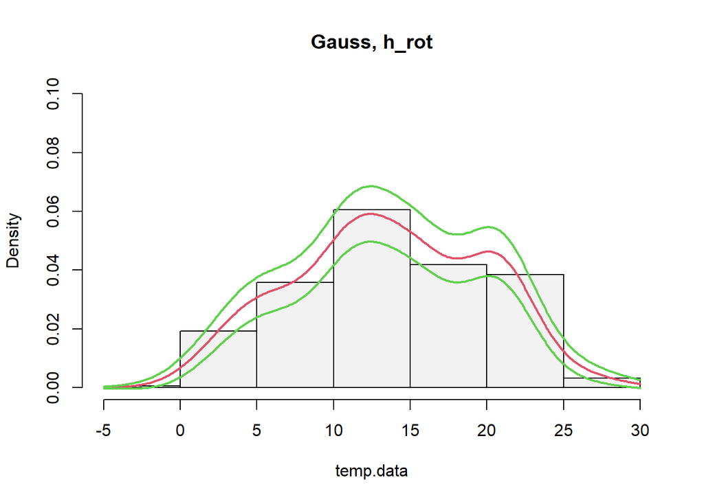

```r
x<- seq(-5,30, by=0.1)
hist(temp.data, freq=FALSE, ylim=c(0,0.1), col="grey95", main="Gauss, h_rot")
estimate<- est.density(temp.data, x, h=1.99, "gauss")
lines(x,estimate$est, col=2, lwd=2)
lines(x,estimate$lower, col=3, lwd=2)
lines(x,estimate$upper, col=3, lwd=2)
```

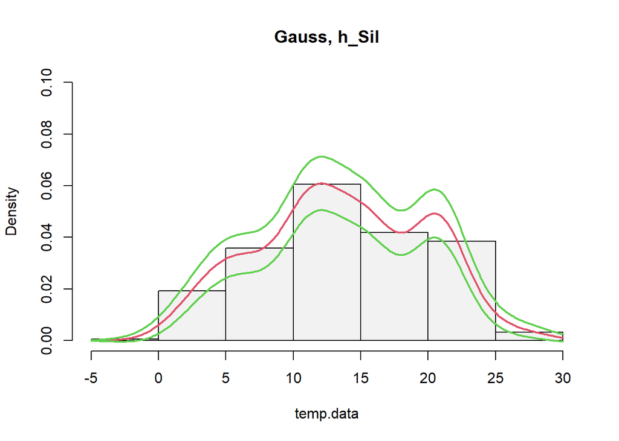

```r
x<- seq(-5,30, by=0.1)
hist(temp.data, freq=FALSE, ylim=c(0,0.1), col="grey95", main="Gauss, h_Sil")
estimate<- est.density(temp.data, x, h=1.69, "gauss")
lines(x,estimate$est, col=2, lwd=2)
lines(x,estimate$lower, col=3, lwd=2)
lines(x,estimate$upper, col=3, lwd=2)
```

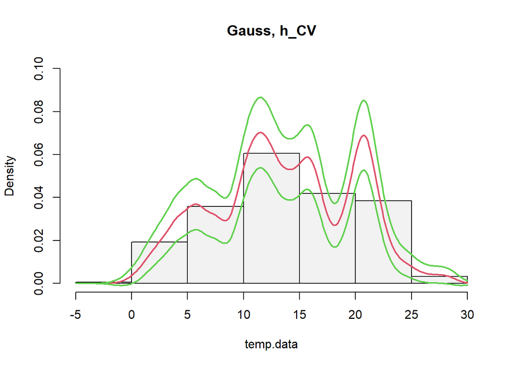

```r
x<- seq(-5,30, by=0.1)
hist(temp.data, freq=FALSE, ylim=c(0,0.1), col="grey95", main="Gauss, h_CV")
estimate<- est.density(temp.data, x, h=0.78, "gauss")
lines(x,estimate$est, col=2, lwd=2)
lines(x,estimate$lower, col=3, lwd=2)
lines(x,estimate$upper, col=3, lwd=2)
```

It is noted that the cross-validated bandwidth is considerably smaller than the asymptotically optimal bandwidths, so this bandwidth choice has plausibly done a better job at removing the bias term and hence would likely lead to better coverage properties of this confidence interval. However, the available theory does not allow us to quantify or verify this notion more precisely, for a real data set with finite sample size.

Next we also compare with the results for the Epanechnikov and Uniform kernels. We take Silverman’s bandwidth as reference value and recompute the bandwidths according to Sec 3.3.4 as

```r
h.epa<- 1.69*2.236
h.uni<- 1.69*1.73
```

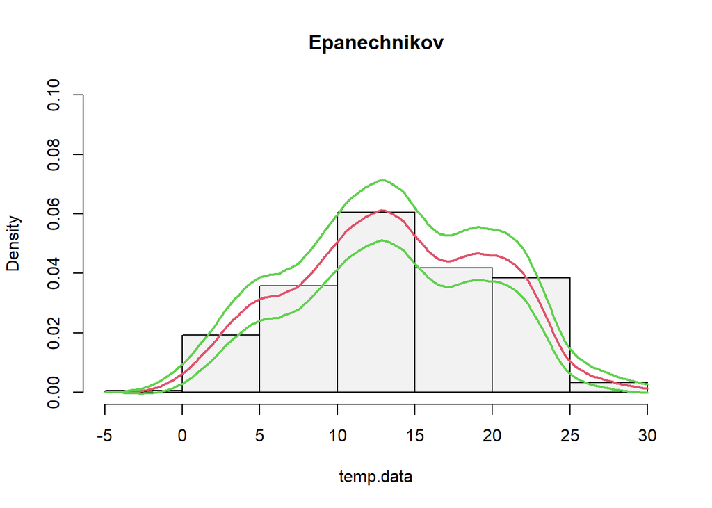

```r
x<- seq(-5,30, by=0.1)
hist(temp.data, freq=FALSE, ylim=c(0,0.1), col="grey95", main="Epanechnikov")
estimate<- est.density(temp.data, x, h=h.epa, "epa")
lines(x,estimate$est, col=2, lwd=2)
lines(x,estimate$lower, col=3, lwd=2)
lines(x,estimate$upper, col=3, lwd=2)
```

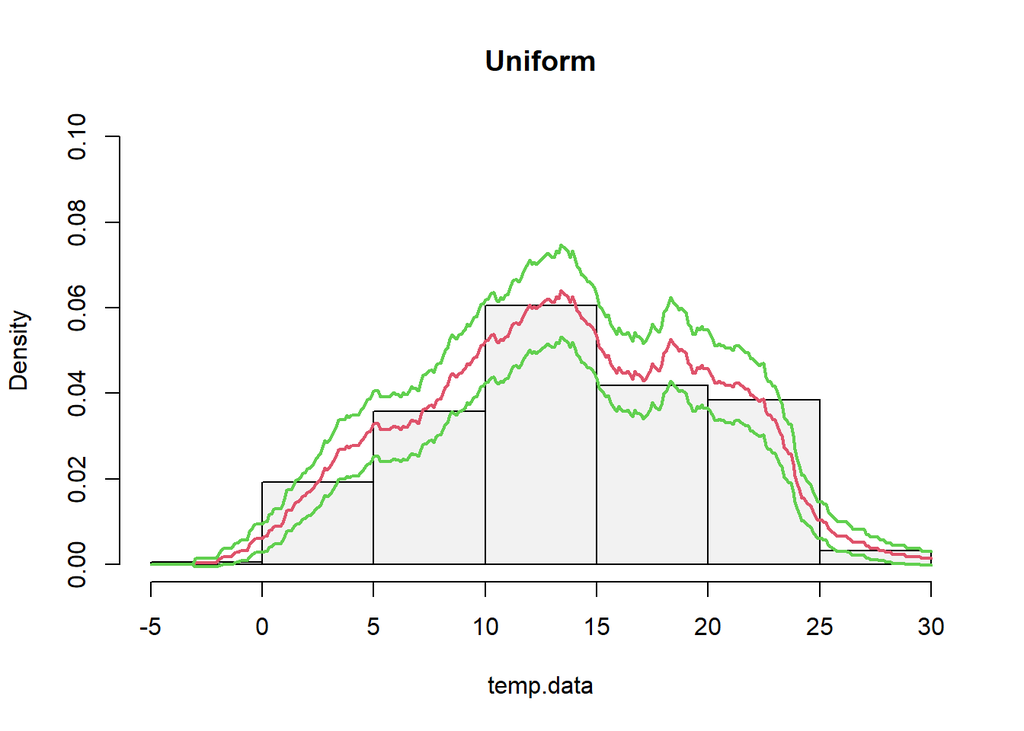

```r
x<- seq(-5,30, by=0.1)
hist(temp.data, freq=FALSE, ylim=c(0,0.1), col="grey95", main="Uniform")
estimate<- est.density(temp.data, x, h=h.uni, "uni")
lines(x,estimate$est, col=2, lwd=2)
lines(x,estimate$lower, col=3, lwd=2)
lines(x,estimate$upper, col=3, lwd=2)
```

## 3.4 Multivariate density estimation

We are given $d$- variate random samples $x_i=(x_{i1}, \ldots, x_{id})^T \in \mathbb{R}^d$, $i=1, \ldots, n$, from a density $f:\mathbb{R}^d \longrightarrow \mathbb{R}_0^+$.

Task: For a given $x \in \mathbb{R}^d$, estimate $f(x)$.

### 3.4.1 The multivariate KDE

Recall the 1-dimensional KDE in the formulation
$$\hat{f}_h(x)= \frac{1}{n}\sum_{i=1}^nK_{h_1}(x_i-x),$$

is a sum of $n$ “bumps”, centered at the $x_i$, each with $\int K_h(x-x_i)\,dx=1$.

The idea for $d$-dimensional KDE is simply to use $d$-variate bumps, centered at the $x_i\in \mathbb{R}^d$, $i=1, \ldots,n$. For instance, one can use densities of multivariate normal $N(x_i, H)$ distributions for some bandwidth matrix

$$H=\left(\begin{array}{ccc} h_1^2 & & * \\
& \ddots & \\
* & & h_d^2
\end{array} \right)$$

where $h_j$ is the bandwidth in direction $j=1, \ldots, d$, and the off-diagonal elements $*$ are usually taken to be zero (but could also be something else).

So (again in the normal case), we can write

$$K_H(x-x_i)= \frac{1}{(2\pi)^{d/2}}\frac{1}{|H|^{1/2}}\exp\left\{-\frac{1}{2}(x-x_i)^TH^{-1}(x-x_i) \right\}$$
so that
$$\hat{f}_H(x)= \frac{1}{n}\sum_{i=1}^nK_H(x-x_i)$$
is a $d$-variate KDE for $f(x)$.

**Example 3.12**

We are given a data set on characteristics of $n=48$ soil samples. We initially only consider $d=2$ variables, namely

- Mg (magnesium in me/100 gm)
- Ca (calcium in me/100 gm)

(Here, me/100 gm denotes “milliequivalents per 100 grams of soil”, a measure the amount of a substance based on its chemical charge, which is a standard unit in soil chemistry).

```r
require(carData)
```

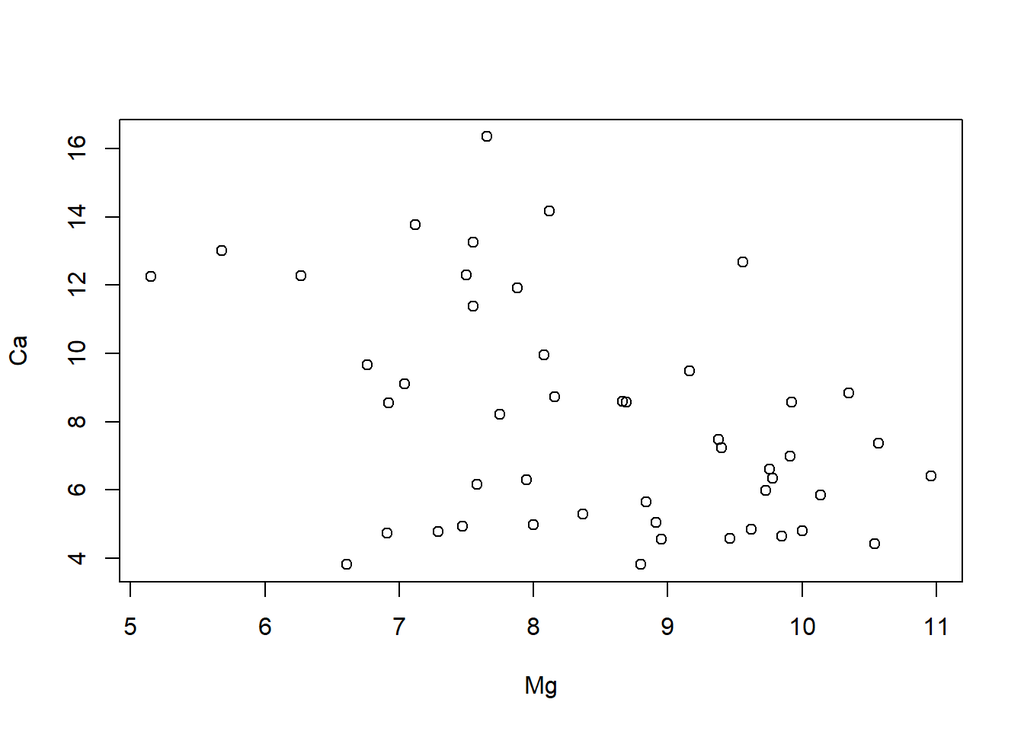

```r
data(Soils)
soils<- Soils[,c("Mg", "Ca")]
plot(soils)
```

We would like to produce a kernel density estimate for this bivariate data set. Therefore we would like to adapt the above introduced, generic formula for the d-variate KDE, to the bivariate case. For the sake of notation let us say that the bivariate data take the form
$$x_i = \left(\begin{array}{c} y_i \\ z_i\end{array}\right)\in \mathbb{R}^2, i=1, \ldots, n.$$
We also assume that we work with a diagonal bandwidth matrix of shape

$$H= \left(\begin{array}{cc} h_1^2 & 0 \\ 0 & h_2^2\end{array}\right).$$
Then we can write

$$\begin{align}
\hat{f}_H(x)&= \frac{1}{n}\sum_{i=1}^nK_H(x-x_i)\\
&= \frac{1}{n}\sum_{i=1}^n\frac{1}{2\pi}\frac{1}{h_1h_2}\exp\left\{-\frac{1}{2}(y-y_i, z-z_i) \left(\begin{array}{cc} 1/h_1^2 & 0 \\ 0 & 1/h_2^2 \end{array} \right)
\left(\begin{array}{c} y-y_i\\z-z_i\end{array}\right)
\right\}\\
&= \frac{1}{n}\sum_{i=1}^n\frac{1}{2\pi}\frac{1}{h_1h_2}\exp\left\{ -\frac{1}{2}\left[\left(\frac{y-y_i}{h_1} \right)^2+ \left(\frac{z-z_i}{h_2} \right)^2 \right]\right\}\\
&=\frac{1}{n}\sum_{i=1}^n\frac{1}{\sqrt{2\pi}h_1}e^{-\frac{1}{2}\left(\frac{y-y_i}{h_1} \right)^2} \times \frac{1}{\sqrt{2\pi}h_2}e^{-\frac{1}{2}\left(\frac{z-z_i}{h_2} \right)^2}\\
&= \frac{1}{n}\sum_{i=1}^n K_{h_1}(y-y_i)K_{h_2}(z-z_i)\\
&= \frac{1}{nh_1h_2}\sum_{i=1}^nK\left(\frac{y-y_i}{h_1}\right) K\left(\frac{z-z_i}{h_2}\right)
\end{align}$$

where $K(u)= \frac{1}{\sqrt{2\pi}}e^{-u^2/2}$ is the 1-dim Gaussian kernel. The conclusion from this derivation is that an easy way to implement multivariate kernels is by simply multiplying the univariate versions. (This is best appreciated by reading the equations from bottom to top!)

We now produce an implementation of the 2-dimensional case, which makes use of the product representation just derived.

```r
my.2d.density<- function(data,x,h){
  # note that `data` is now a matrix, and x, h are vectors
  data <- na.omit(data)
  n <- dim(data)[1]
  d <- dim(data)[2]
  if (d!=2){stop("Incorrect data dimension: d=2 required")}
  denom<- n*h[1]*h[2]
  num<- sum(my.kernel((data[,1]-x[1])/h[1])*my.kernel((data[,2]-x[2])/h[2]) )
  return(num/denom)
}
```

Assuming that `my.kernel` is set to be the Gaussian kernel, the result is:

```r
x<- seq(1,20, by=0.5)
y<-  seq(1,20, by=0.5)
G<-length(x)
fit.soil<- matrix(0, nrow=G, ncol=G)
for (j in 1:G){
  for (k in 1:G){
  fit.soil[j,k]<- my.2d.density(soils,c(x[j], y[k]),c(1,1))
  # uses h=1 in both directions
  }
  }
```

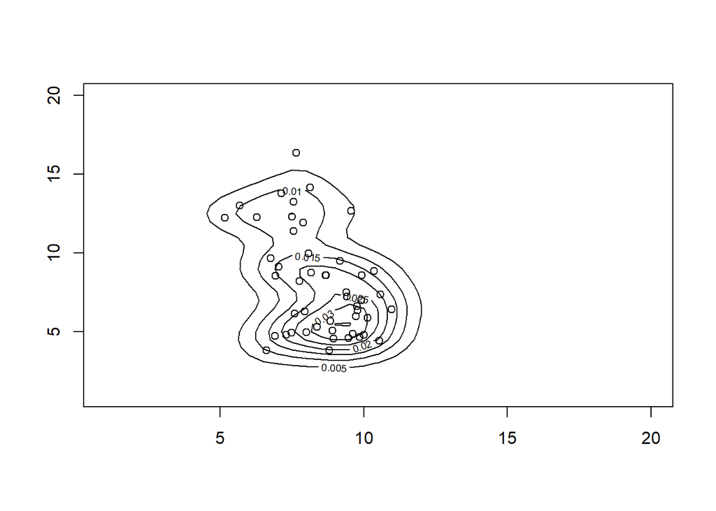

```r
contour(x,y,fit.soil)

points(soils)
```

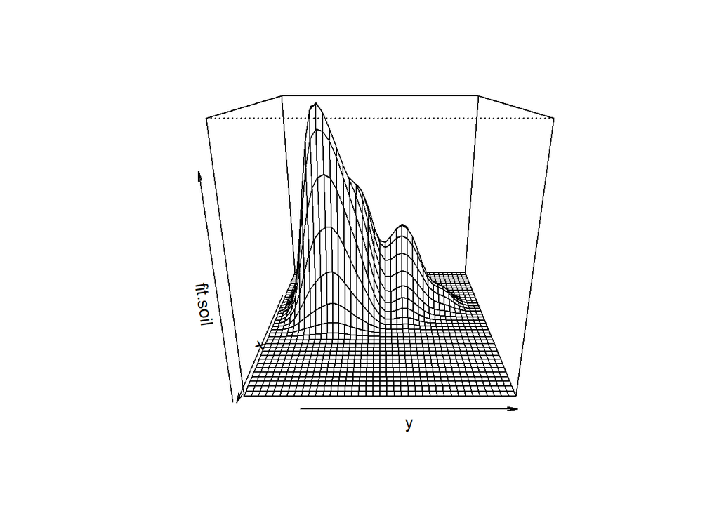

```r
persp(x,y, fit.soil, phi=20, theta=90)
```

Similarly to the 1-dim notation
$$K_h(x-x_i)= \frac{1}{h}K\left(\frac{x-x_i}{h} \right)$$
we can write more generally in $d$ dimensions

$$K_H(x-x_i)= \frac{1}{|H|^{1/2}}K\left(H^{-1/2}(x-x_i) \right)$$
where $K:\mathbb{R}^d\longrightarrow \mathbb{R}_0^+$ is a d-variate kernel, i.e. a symmetric, bounded, unimodal function such that
$$\int_{u_d}\ldots \int_{u_1}K(u_1, \ldots, u_d)d_{u_1}\ldots d_{u_d}\equiv \int K(u)\,du=1.$$
For instance, the Gauss kernel in $d$ dimensions is given by $K(u)=\frac{1}{(2\pi)^{d/2}}\exp\left\{-\frac{1}{2}u^Tu\right\}$, and $H \in \mathbb{R}^{d \times d}$ is a symmetric and positive definite bandwidth matrix.

### 3.4.2 Optimal bandwidth matrices

Based on similar calculations as in Sections 3.3.5 to 3.3.7, and then extending the idea of “normal reference” to the $d$-variate case, one obtains he optimal bandwidth matrix for $d>1$ as

$$H_{opt}= \left(\frac{4}{d+2}\right)^{2/(d+4)}n^{-2/(d+4)}\hat{\Sigma}$$
where $\hat{\Sigma}=\frac{1}{n-1}\sum_{i=1}^n(x_i-\bar{x})(x_i-\bar{x})^T$ is the estimated variance matrix (Wand & Jones, Sec 4.9). If one uses
$$\hat{\Sigma}= \left(\begin{array}{ccc}\hat{\sigma}_1^2 & & \\
& \ddots & \\
& & \hat{\sigma_d}^2
\end{array}\right)$$

where $\hat{\sigma}_j$ is the standard deviation of the $j$th variable, then

$$H_{opt}= \left(\begin{array}{ccc}h_{1, opt}^2 & & \\
& \ddots & \\
& & h_{d, opt}^2
\end{array}\right)$$
with
$$h_{j, opt}= \left(\frac{4}{d+2}\right)^{1/d+4}n^{-1/(d+4)}\hat{\sigma}_j$$
for $j=1, \ldots, d$. Noting that the leading multiplicative term is $\approx 1$ (see example below), this leads to the surprisingly simple rule-of-thumb formula
$$h_{j, ROT}= \hat{\sigma}_jn^{-1/(d+4)}$$
This is known as **Scott’s rule in $\mathbb{R}^d$**.

**Example 3.13**

Check that the multiplicative leading term of $h_{opt}$ is approximately 1:

```r
d<- 1:20
(4/(d+2))^(1/(d+4))
```

```
##  [1] 1.0592238 1.0000000 0.9686251 0.9505798 0.9397142 0.9330330 0.9289309
##  [8] 0.9264849 0.9251351 0.9245277 0.9244309 0.9246891 0.9251954 0.9258747
## [15] 0.9266738 0.9275544 0.9284884 0.9294556 0.9304408 0.9314329
```

Then implement $h_{ROT}$:

```r
hd.rot<- function(data){
  data<-na.omit(data)
  n<-dim(data)[1]
  d<-dim(data)[2]
  hopt<-rep(0,d)
  for (j in 1:d){
    sigmaj<-sd(data[,j])
    hopt[j]<- sigmaj*n^{-1/(d+4)}
  }
return(hopt)
}
```

Apply on 2-dim soils data

```r
h.soil2<-hd.rot(soils)
h.soil2
```

```
## [1] 0.717701 1.707931
```

Estimate the KDE with these bandwidths:

```r
x<- seq(1,20, by=0.5)
y<-  seq(1,20, by=0.5)
G<-length(x)
fit.soil<- matrix(0, nrow=G, ncol=G)
for (j in 1:G){
  for (k in 1:G){
  fit.soil[j,k]<- my.2d.density(soils,c(x[j], y[k]), h.soil2)
  }
  }
```

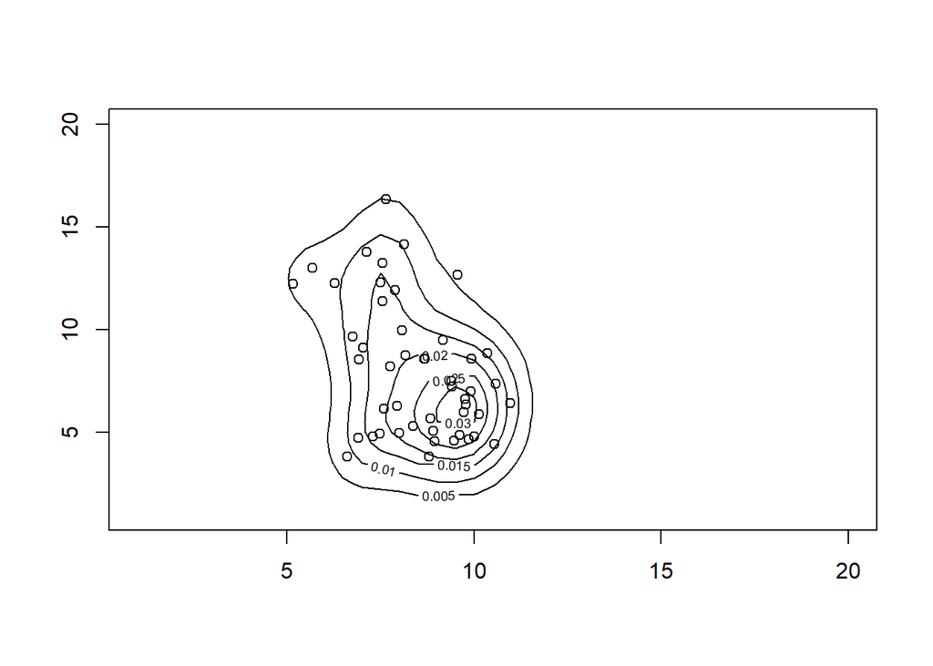

```r
contour(x,y,fit.soil)
points(soils)
```

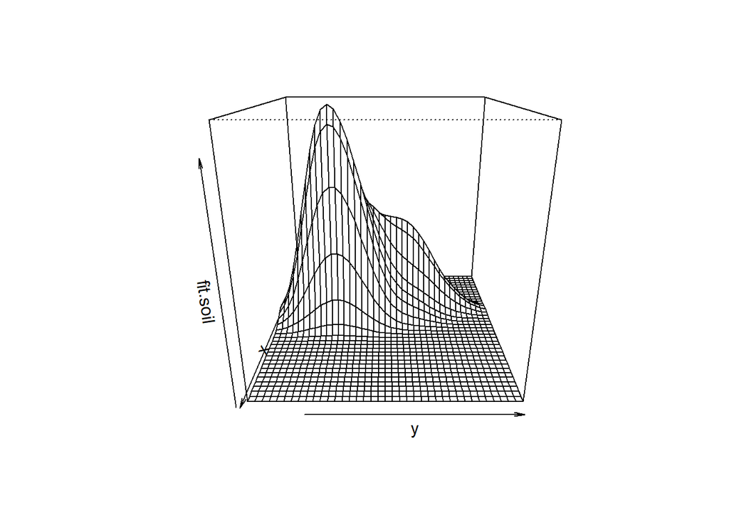

```r
persp(x,y,fit.soil, phi=20, theta=90)
```

We can use also use some ready-built R functions, such as `kde` in package `ks`:

```r
require(ks)
```

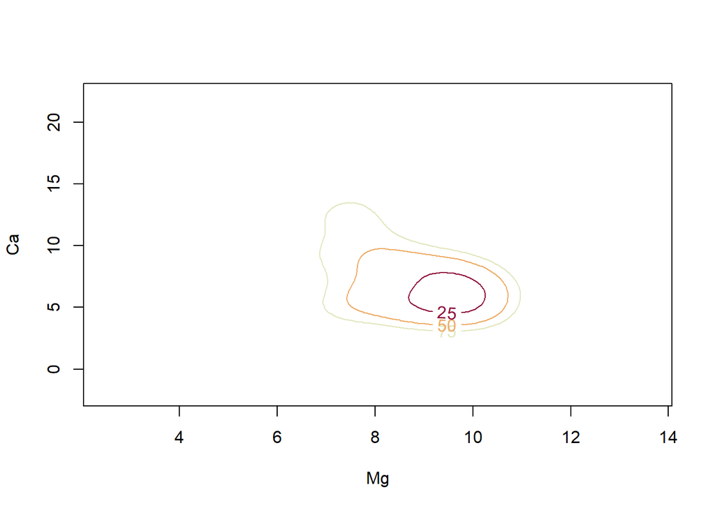

```r
fit.soil1<-kde(soils)
plot(fit.soil1)
```

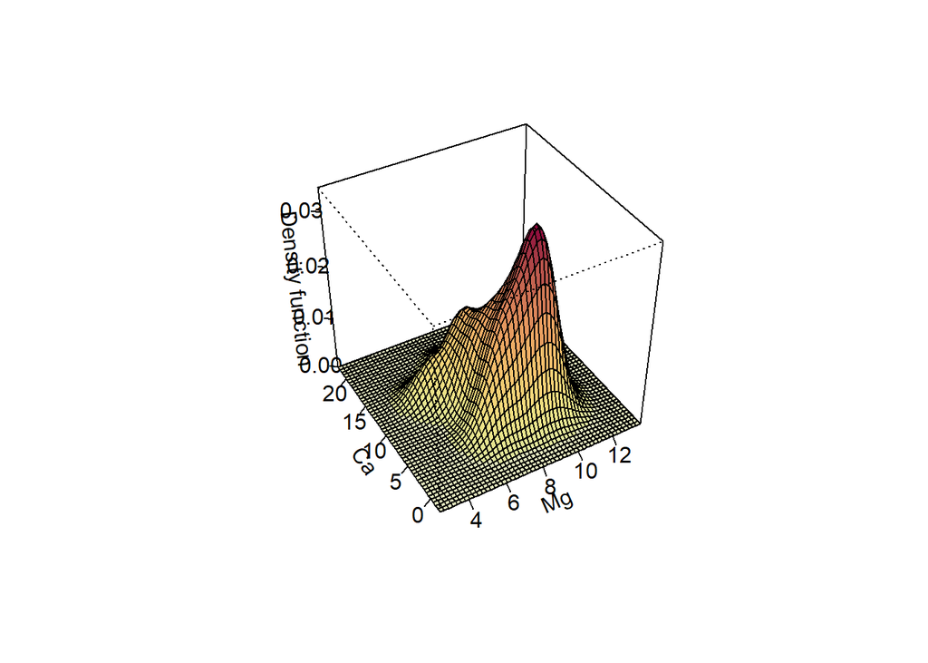

```r
plot(fit.soil1, display="persp")
```

Which bandwidths have been used here? Let’s inspect:

```r
names(fit.soil1)
```

```
##  [1] "x"           "eval.points" "estimate"    "H"           "gridtype"
##  [6] "gridded"     "binned"      "names"       "w"           "type"
## [11] "cont"
```

```r
sqrt(fit.soil1$H)
```

```
##           [,1]     [,2]
## [1,] 0.7314344      NaN
## [2,]       NaN 1.578264
```

The result is of this is slightly different than from our ROT since the `Hpi` bandwidth used in `kde` does not use normal reference, but instead estimates a pilot density first, from which the integrated second derivatives are estimated. We can still use Scott’s bandwidth by plugging it manually into `kde`:

```r
fit.soil2 <- kde(soils, H=diag(h.soil2^2))
sqrt(fit.soil2$H)
```

```
##          [,1]     [,2]
## [1,] 0.717701 0.000000
## [2,] 0.000000 1.707931
```

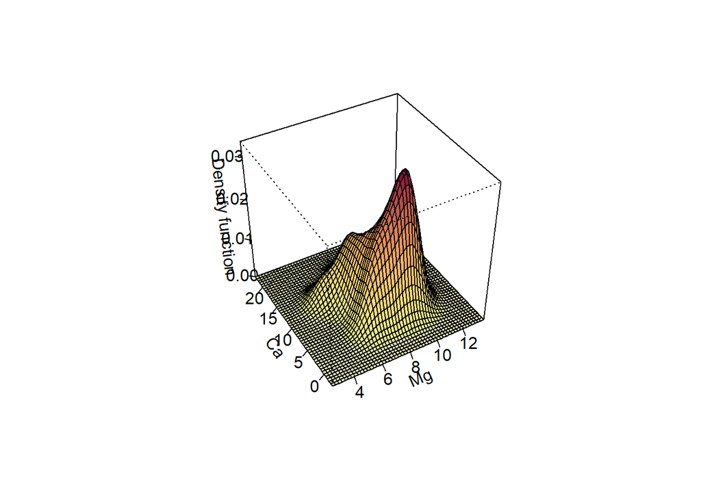

```r
plot(fit.soil2, display="persp")
```

There are some further graphical options which one may find neat…

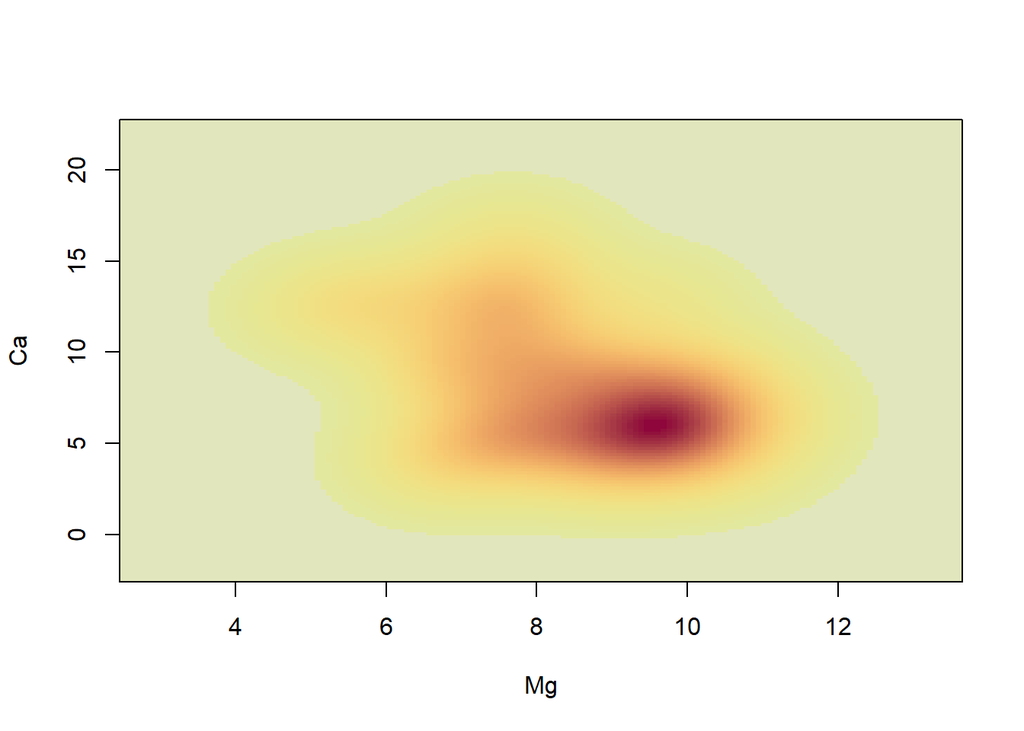

```r
# ?plot.kde
plot(fit.soil2, display="image")
```

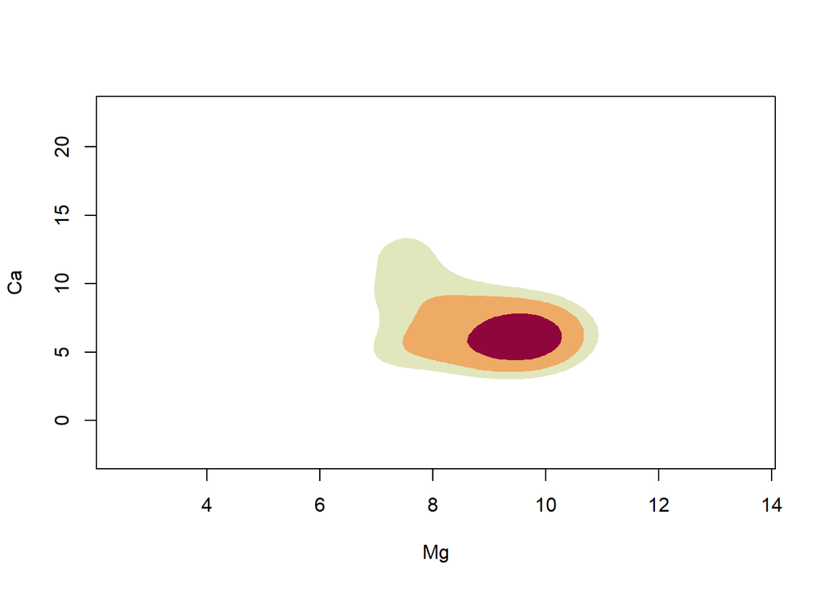

```r
plot(fit.soil2, display="filled.contour")
```